# Agent-Based Modeling for Statisticians

A Short Course

John S. Schuler

Joint Statistical Meetings, 2026

# 1 The Differential Equations of Living Systems

```r
# Chapter 1 Setup
# All packages and global settings for this chapter.
# This chunk is self-contained — it does not depend on any prior chapter.

library(tidyverse)
library(deSolve)
library(patchwork)

theme_set(
  theme_minimal(base_family = "Source Serif 4") +
    theme(
      plot.title       = element_text(family = "Raleway", face = "plain",
                                      size = 14, margin = margin(b = 8)),
      plot.subtitle    = element_text(family = "Source Serif 4", size = 11,
                                      color = "#555555", margin = margin(b = 12)),
      axis.title       = element_text(family = "Source Serif 4", size = 10),
      legend.position  = "bottom",
      panel.grid.minor = element_blank(),
      plot.background  = element_rect(fill = "#FAFAF7", color = NA)
    )
)

palette_ch1 <- c(
  prey        = "#2D5F8A",
  predator    = "#8A4A2D",
  susceptible = "#2D5F8A",
  infectious  = "#C0392B",
  recovered   = "#27AE60"
)
```

A population of rabbits with unlimited food grows exponentially. Or does it? After all, the fox population grows with it — and then the rabbits decline — and then the foxes, deprived of prey, decline in turn — and then the rabbits recover. We expect growth to continue or stop; not to cycle. We expect an epidemic to burn through everyone it can reach. These expectations are wrong, and they are wrong in the same way: something in the process is feeding back on the conditions of its own continuation. (Lotka 1925; Volterra 1926a) Human intuition handles feedback poorly.

The differential equation is the instrument built for exactly this. The state determines the rate; the rate changes the state; the new state determines a new rate — the equation captures this self-referential loop and makes it tractable.

Alas, familiar equations, over time, render their assumptions invisible. The predator-prey model and the epidemic model are a century old; the choices embedded in their functional forms have had that long to become invisible. What is hiding in those forms — and what it costs to have those things hidden — is what the rest of this course is about.

For statisticians, the central question is not whether agent-based models are more realistic but rather: which distinctions does the inference require? If heterogeneity, contact dependence, discreteness, or temporal ordering affect the phenomenon, then an aggregate model that omits them is not merely simpler. It belongs to a model family in which those distinctions cannot affect the answer.

## 1.1 Predators, Prey, and the Geometry of Cycles

Begin with the prey. Absent predators, a prey population grows at a rate proportional to its size — each individual produces offspring at the same per-capita rate $\alpha$, and the population is not resource-constrained. This gives the exponential growth term $\alpha N$. Predators, absent prey, decline at a per-capita rate $\gamma$ — they die without food. These are the uncoupled dynamics: rabbits grow, foxes die.

Coupling enters through encounters. A predator that encounters a prey individual kills it with some probability; the encounter benefits the predator. The rate at which these encounters occur is proportional to the product $NP$. This deserves a moment’s attention before the equation appears. The product $NP$ says that every predator is equally likely to encounter every prey individual: if there are twice as many prey, encounters double; if there are twice as many predators, encounters double. The encounter rate is the product of the two abundances, multiplied by a rate constant $\beta$ that converts encounters into kills.

$$\frac{dN}{dt} = \alpha N - \beta N
P$$

$$\frac{dP}{dt} = \delta N P - \gamma
P$$

The parameter $\alpha$ is the prey birth rate; $\beta$ is the predation rate coefficient — the probability per unit time per predator-prey pair that an encounter results in a kill; $\delta$ is the conversion efficiency, the rate at which prey consumed is converted into predator offspring; $\gamma$ is the predator death rate. Four parameters. Two equations. A complete description of a world with two species and one interaction. (Lotka 1925; Volterra 1926b)

**Activity — Predict Before Computing (10 minutes)**

Starting from $N(0)=10$ prey and $P(0)=5$ predators, sketch both populations through time. Mark which population peaks first and decide whether the cycles grow, shrink, or remain constant. Then compare sketches with a partner and identify the assumption doing the most work in your prediction. Do not solve the equations before committing to a sketch.

The nullclines — the curves along which each population is momentarily stationary — divide the phase plane into four regions. The prey nullcline $dN/dt = 0$ requires either $N = 0$ or $P = \alpha/\beta$: the prey population is constant when the predator population is exactly $\alpha/\beta$, regardless of how many prey there are. The predator nullcline $dP/dt = 0$ requires either $P = 0$ or $N = \gamma/\delta$: predators are stationary when prey are at exactly $\gamma/\delta$. The nontrivial equilibrium is the crossing point: $N^* = \gamma/\delta$, $P^* = \alpha/\beta$.

The trajectories are closed orbits around this equilibrium — neither converging to it nor expanding away. The system cycles forever without damping or growth. This is the pendulum that never loses energy, a machine that returns to any given state without ever simplifying toward rest. It is geometrically beautiful and physically strange. A physicist would say the system is conservative — it has a constant of motion, a quantity that is preserved along every trajectory. Volterra showed that $\delta N - \gamma \ln N + \beta P - \alpha \ln P$ is constant along solutions of the system (Volterra 1926b). The orbits are the level curves of this conserved quantity.

Each initial condition $(N_0, P_0)$ selects a particular orbit, and the system follows that orbit infinitely. The orbits nest. The central equilibrium point is not a fixed point in the attracting sense — it is surrounded by a continuous family of periodic orbits which differ in amplitude of the same cycle. The phase plane is therefore not a diagram of what the system tends toward; it is a diagram of what the system does forever.

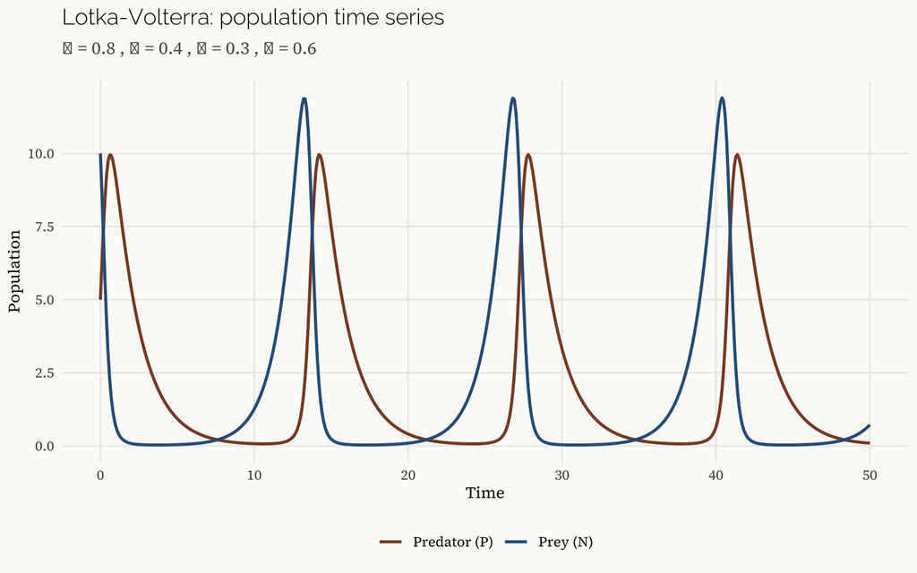

Lotka-Volterra predator-prey dynamics. Prey (blue) and predator (brown) populations cycle indefinitely. Parameters: $\alpha = 0.8$, $\beta = 0.4$, $\delta = 0.3$, $\gamma = 0.6$.

```r
# Lotka-Volterra ODE system
# set.seed not required here — deSolve is deterministic
lv_params <- c(alpha = 0.8, beta = 0.4, delta = 0.3, gamma = 0.6)
lv_state  <- c(N = 10, P = 5)

lv_ode <- function(t, state, params) {
  with(as.list(c(state, params)), {
    dN <- alpha * N - beta * N * P
    dP <- delta * N * P - gamma * P
    list(c(dN, dP))
  })
}

times_lv <- seq(0, 50, by = 0.1)
lv_out   <- ode(y = lv_state, times = times_lv, func = lv_ode, parms = lv_params)

lv_df <- as_tibble(as.data.frame(lv_out)) %>%
  pivot_longer(c(N, P), names_to = "species", values_to = "population") %>%
  mutate(species = recode(species, N = "prey", P = "predator"))

ggplot(lv_df, aes(x = time, y = population, color = species)) +
  geom_line(linewidth = 0.9) +
  scale_color_manual(
    values = palette_ch1[c("prey", "predator")],
    labels = c("prey" = "Prey (N)", "predator" = "Predator (P)")
  ) +
  labs(
    title    = "Lotka-Volterra: population time series",
    subtitle = expression(alpha == 0.8 ~ "," ~ beta == 0.4 ~ "," ~ delta == 0.3 ~ "," ~ gamma == 0.6),
    x        = "Time",
    y        = "Population",
    color    = NULL
  )
```

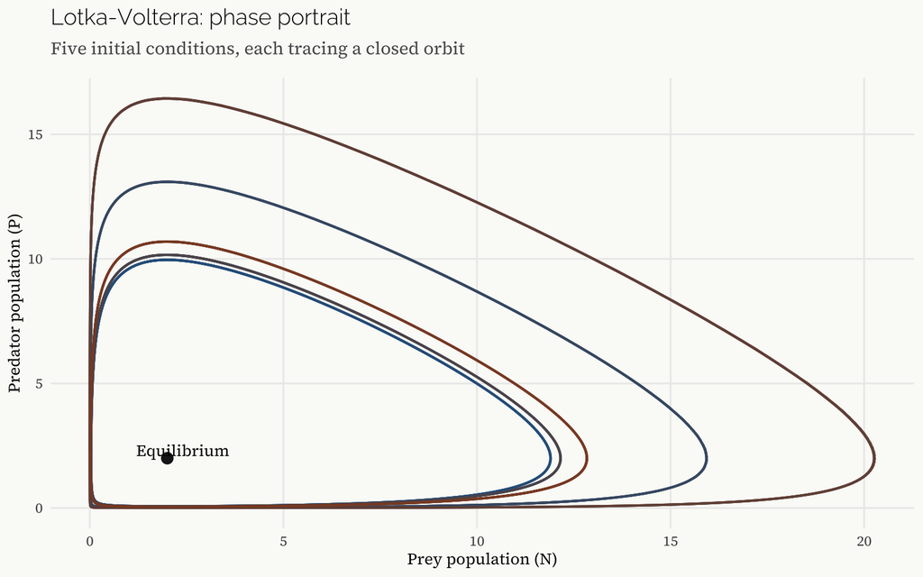

Phase portrait of Lotka-Volterra dynamics. Each curve is a closed orbit corresponding to a different initial condition. The system returns to each point on a given orbit with exact periodicity.

```r
# Phase portrait: multiple initial conditions
# The system is deterministic; no seed needed
initial_conditions <- list(
  c(N = 10, P = 5),
  c(N = 15, P = 4),
  c(N = 8,  P = 7),
  c(N = 20, P = 3),
  c(N = 6,  P = 9)
)

orbit_df <- map_dfr(
  seq_along(initial_conditions),
  function(i) {
    out <- ode(
      y     = initial_conditions[[i]],
      times = seq(0, 80, by = 0.05),
      func  = lv_ode,
      parms = lv_params
    )
    as_tibble(as.data.frame(out)) %>%
      mutate(orbit = factor(i))
  }
)

# Equilibrium point
N_star <- lv_params["gamma"] / lv_params["delta"]
P_star <- lv_params["alpha"] / lv_params["beta"]

ggplot(orbit_df, aes(x = N, y = P, color = orbit)) +
  geom_path(linewidth = 0.7, alpha = 0.8) +
  annotate("point", x = N_star, y = P_star, size = 3, color = "#1C1C1E") +
  annotate("text", x = N_star + 0.4, y = P_star + 0.3,
           label = "Equilibrium", family = "Source Serif 4", size = 3.5) +
  scale_color_manual(values = colorRampPalette(c("#2D5F8A", "#8A4A2D"))(5)) +
  guides(color = "none") +
  labs(
    title = "Lotka-Volterra: phase portrait",
    subtitle = "Five initial conditions, each tracing a closed orbit",
    x = "Prey population (N)",
    y = "Predator population (P)"
  )
```

## 1.2 The Mean-Field Assumption

Within the product term $\beta NP$, hides an assumption in plain sight.

The expression says that the rate of predator-prey encounters is proportional to the product of population sizes. For this to hold, every predator must be equally likely to encounter every prey individual at every moment. The population is perfectly mixed. There is no space and thus no location. Individuals have neither territories, nor persistent relationships. There are no dense patches and no empty expanses. The assumption is that the spatial arrangement is irrelevant because mixing is instantaneous and complete.

We call this the mean-field assumption, borrowing the name from physics, where it appears in the analysis of magnetic systems: the effective field experienced by any one particle is the mean field produced by all the others, rather than the specific field produced by its actual neighbors (Sethna 2021). In population ecology it enters through the functional form of the interaction term — unstated in most presentations of Lotka-Volterra, embedded in the mathematics rather than declared before the equations. The product $NP$ is one modeling choice among others; it is the one that assumes perfect mixing.

The mean-field assumption is a structural model-family choice: it selects the class of models governed by mass-action kinetics, excluding all others — network models, spatial models, individual-based models — prior to any data. The product $NP$ is not a parameter to be estimated. It is the choice of family, and that choice determines what phenomena the family can express. Structured populations, spatial aggregations, social networks among individuals, heterogeneous encounter rates. These are not in the family.

That family choice is simultaneously a choice about temporal resolution. The ODE family is defined in continuous time — formally, the limit as the time step shrinks to zero. But the interaction term $\beta NP$ is appropriate only when the observation interval is coarse enough for the law of large numbers to operate across interactions within each step. At fine enough temporal resolution the family is misspecified: in any given instant most individuals are not contacting most others, and the product term misrepresents the actual contact process. The mean-field ODE is the right family at temporal resolutions coarse enough for spatial averaging to hold within each step. Whether that condition is satisfied is an empirical question about the system’s contact dynamics — not a modeling convenience.

The clean closed-orbit result depends on this assumption. When real predator-prey systems fail to cycle as neatly as the model predicts, the mean-field assumption may be the culprit. Its most important consequences, however, will not come into view until the contrast with agent-based models is drawn.

## 1.3 Epidemics and the Threshold Phenomenon

The same assumption appears in epidemic modeling, in precisely the same place, governing a different interaction.

Consider a closed population of $N$ individuals. Each is in one of three states: Susceptible, Infectious, or Recovered (and immune). Infectious individuals shed pathogen; susceptible individuals become infected upon exposure. The rate at which susceptible individuals encounter infectious ones is proportional to $SI$ — the number of susceptibles times the number of infecteds, multiplied by a rate constant $\beta$. Recovery occurs at per-capita rate $\gamma$. (Kermack and McKendrick 1927)

$$\frac{dS}{dt} = -\beta S I$$

$$\frac{dI}{dt} = \beta S I - \gamma
I$$

$$\frac{dR}{dt} = \gamma I$$

The mean-field assumption is here again: the contact rate is proportional to the product $SI$, which assumes that every susceptible individual is equally likely to contact every infectious individual. Human contact, of course, is not structured this way. People have households, workplaces, social networks — structures that make some contacts far more probable than others. The SIR model, like Lotka-Volterra, assumes this structure away.

From the sign of $dI/dt$ at the start of an epidemic, when $S \approx N$:

$$\frac{dI}{dt}\bigg|_{t=0} \approx
I(\beta N - \gamma) = I \cdot \gamma\left(\frac{\beta N}{\gamma} -
1\right)$$

The epidemic grows if $\beta N / \gamma > 1$ and dies out if $\beta N / \gamma < 1$. The quantity $\mathcal{R}_0 = \beta N / \gamma$ is the basic reproduction number: the expected number of secondary infections produced by a single infectious individual in a fully susceptible population (Kermack and McKendrick 1927; Hethcote 2000). It is not a numerical fact to memorize. It is a structural consequence of the model — a ratio between the transmission term and the recovery term, visible directly in the algebra. The epidemic threshold at $\mathcal{R}_0 = 1$ is where the production of new infections exactly balances the removal of current ones.

In the years since 2020 many of us have thought more about this model than we ever ancitipated. The herd immunity threshold, the effect of contact reduction, the role of $\mathcal{R}_0$ in policy discussions — these became household concepts in a span of weeks. What remained, for the most part, unstated in those discussions was the mean-field assumption underlying the standard SIR framework: that the contact structure of the population could be adequately represented by the product $SI$, ignoring the network topology that governs who actually contacts whom.

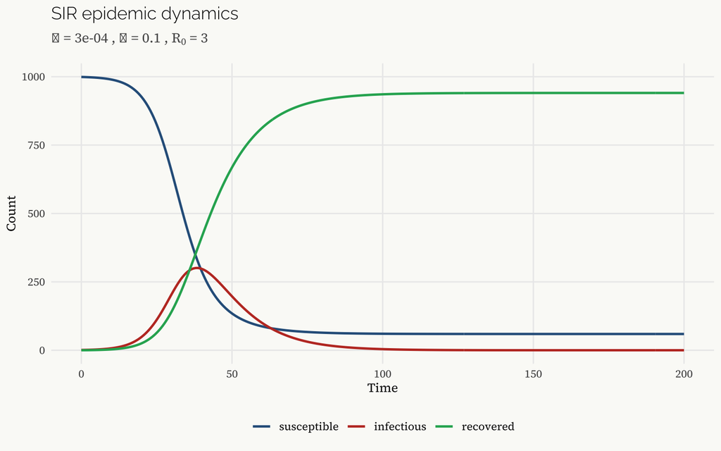

SIR epidemic dynamics. The epidemic rises, peaks when the susceptible pool is depleted sufficiently, and declines. The herd immunity threshold is reached when enough individuals have recovered that $\mathcal{R}_0 S/N < 1$.

```r
# SIR ODE implementation
sir_params <- c(beta = 0.0003, gamma = 0.1)
sir_state  <- c(S = 999, I = 1, R = 0)
N_pop      <- sum(sir_state)

# R0 under these parameters
R0_base <- sir_params["beta"] * N_pop / sir_params["gamma"]

sir_ode <- function(t, state, params) {
  with(as.list(c(state, params)), {
    dS <- -beta * S * I
    dI <-  beta * S * I - gamma * I
    dR <-  gamma * I
    list(c(dS, dI, dR))
  })
}

times_sir <- seq(0, 200, by = 0.5)
sir_out   <- ode(y = sir_state, times = times_sir, func = sir_ode, parms = sir_params)

sir_df <- as_tibble(as.data.frame(sir_out)) %>%
  pivot_longer(c(S, I, R), names_to = "compartment", values_to = "count") %>%
  mutate(
    compartment = factor(
      compartment,
      levels = c("S", "I", "R"),
      labels = c("susceptible", "infectious", "recovered")
    )
  )

ggplot(sir_df, aes(x = time, y = count, color = compartment)) +
  geom_line(linewidth = 0.9) +
  scale_color_manual(
    values = palette_ch1[c("susceptible", "infectious", "recovered")]
  ) +
  labs(
    title    = "SIR epidemic dynamics",
    subtitle = bquote(beta == .(sir_params["beta"]) ~ "," ~
                      gamma == .(sir_params["gamma"]) ~ "," ~
                      R[0] == .(round(R0_base, 2))),
    x        = "Time",
    y        = "Count",
    color    = NULL
  )
```

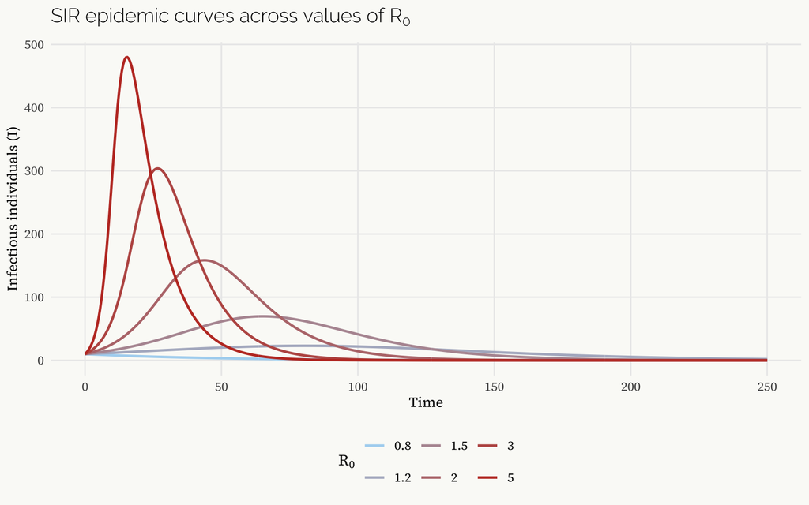

SIR epidemic curves across values of $\mathcal{R}_0$. Each curve shows the infectious compartment $I(t)$ for a different transmission rate. The epidemic threshold at $\mathcal{R}_0 = 1$ is visible: below it, no outbreak occurs; above it, epidemic size grows with $\mathcal{R}_0$.

```r
# Parameter sweep over R0
# Vary beta to produce different R0 values; gamma and N fixed

set.seed(2025)  # seed for reproducibility; results are deterministic here, but good practice

R0_values <- c(0.8, 1.2, 1.5, 2.0, 3.0, 5.0)
gamma_fixed <- 0.1
N_fixed     <- 1000

sweep_df <- map_dfr(R0_values, function(r0) {
  beta_val <- r0 * gamma_fixed / N_fixed
  params_i <- c(beta = beta_val, gamma = gamma_fixed)
  state_i  <- c(S = N_fixed - 10, I = 10, R = 0)
  out_i    <- ode(y = state_i, times = seq(0, 250, by = 0.5),
                  func = sir_ode, parms = params_i)
  as_tibble(as.data.frame(out_i)) %>%
    mutate(R0 = r0) %>%
    select(time, I, R0)
})

ggplot(sweep_df, aes(x = time, y = I, color = factor(R0), group = factor(R0))) +
  geom_line(linewidth = 0.85) +
  scale_color_manual(
    values = colorRampPalette(c("#AED6F1", "#C0392B"))(length(R0_values)),
    name   = expression(R[0])
  ) +
  labs(
    title = expression("SIR epidemic curves across values of" ~ R[0]),
    x     = "Time",
    y     = "Infectious individuals (I)"
  )
```

## 1.4 What the Language Can Say

A differential equation governing $dN/dt$ must treat $N$ as something smooth enough to differentiate: a real number rather than a count. The prey population $N = 3.7$ is as valid a model state as $N = 37$ or $N = 370$. The formalism is not approximating a discrete reality; it is positing a different one. Individuals are absent. Only totals exist.

From the decision to track totals, the rest follows by a logical chain with no exits. A total has no internal distribution: the ODE has only $N$, so all prey individuals must be identical — same predation risk, same birth rate. A real fox population contains young and old, healthy and sick, bold hunters and timid ones. The ODE contains none of this.

Identical individuals interacting through their totals: the mean-field assumption, arrived at not by declaration but by consequence. If all prey individuals are equivalent, the encounter rate is proportional to $N$, independently of position or history. The product $\beta NP$ follows immediately — a consequence of the prior two choices, not a third independent assumption. Space disappears because individuals have no positions; history disappears because two numbers are all the state there is.

These choices have been scientifically productive for over a century. Lotka-Volterra was formulated in the 1920s (Lotka 1925; Volterra 1926a); SIR was published in 1927 by Kermack and McKendrick (Kermack and McKendrick 1927). The models have generated real insight into predator-prey dynamics, epidemic thresholds, herd immunity. The chain — continuity, homogeneity, mean-field, no position, no history — was forged in a few equations and has persisted every since. The product term $\beta NP$ is this commitment. When it fits, the model is the right instrument. When it fails, the model gives precise answers — about an imaginary world.

# 2 Agents, Networks, and the Geometry of Interaction

```r
# Chapter 2 Setup
# Self-contained — does not depend on Chapter 1.

library(tidyverse)
library(deSolve)
library(igraph)
library(tidygraph)
library(ggraph)
library(gganimate)
library(patchwork)

theme_set(
  theme_minimal(base_family = "Source Serif 4") +
    theme(
      plot.title       = element_text(family = "Raleway", face = "plain",
                                      size = 14, margin = margin(b = 8)),
      plot.subtitle    = element_text(family = "Source Serif 4", size = 11,
                                      color = "#555555", margin = margin(b = 12)),
      axis.title       = element_text(family = "Source Serif 4", size = 10),
      legend.position  = "bottom",
      panel.grid.minor = element_blank(),
      plot.background  = element_rect(fill = "#FAFAF7", color = NA)
    )
)

palette_ch2 <- c(
  prey        = "#2D5F8A",
  predator    = "#8A4A2D",
  susceptible = "#2D5F8A",
  infectious  = "#C0392B",
  recovered   = "#27AE60"
)

# ODE parameters derived from the ABM individual-level rates:
#   alpha = p_birth = 0.15   (per-capita prey birth rate per step)
#   gamma = p_death = 0.10   (per-capita predator death rate per step)
#   beta  = p_kill  = 0.00375 (kill probability per predator-prey pair per step)
#   delta = p_kill * p_convert = 0.00375 * 0.267 ≈ 0.001 (predator birth rate)
# Equilibrium: N* = gamma/delta = 100, P* = alpha/beta = 40.
# Starting at (N=200, P=40): N is above N*, P is at P*, so P rises first
# while N stays near 200, then both oscillate. Period ≈ 51 steps.
lv_params_ch2 <- c(alpha = 0.15, beta = 0.00375, delta = 0.001, gamma = 0.10)
lv_ode_ch2 <- function(t, state, params) {
  with(as.list(c(state, params)), {
    dN <- alpha * N - beta * N * P
    dP <- delta * N * P - gamma * P
    list(c(dN, dP))
  })
}

sir_params_ch2 <- c(beta = 0.0003, gamma = 0.1)
sir_ode_ch2 <- function(t, state, params) {
  with(as.list(c(state, params)), {
    dS <- -beta * S * I
    dI <-  beta * S * I - gamma * I
    dR <-  gamma * I
    list(c(dS, dI, dR))
  })
}
```

## 2.1 What Is an Agent?

The ODE compresses a population of a hundred rabbits to the number 100 — a total that absorbs their individual differences into a single quantity. The agent-based model takes those hundred rabbits seriously as a hundred rabbits. Each has a state. Each has a neighborhood: the set of other agents it can actually interact with at this time step. (Epstein and Axtell 1996) The moment a neighborhood is anything other than “the entire population, uniformly weighted,” the mean-field assumption fails and the right answer falls outside the model’s language.

Give an agent a neighborhood smaller than the full population, and you give the model a new kind of sentence. The neighborhood can be spatial — the eight cells surrounding a position on a grid. It can be social — the edges of a contact network.

## 2.2 An Agent-Based Lotka-Volterra

The biology is unchanged. Prey reproduce, predators hunt, predators die — the same rules as the differential equations. What changes is the substrate: a population of discrete individuals rather than a continuous quantity.

Each individual is a row in a `tibble` carrying an identifier, a type (prey or predator), and an alive status. At each discrete time step: each surviving prey reproduces with probability $p_\text{birth}$; each predator independently encounters each prey individual with probability $p_\text{kill}$, killing it on contact; each kill produces a new predator with probability $p_\text{convert}$; each predator dies independently with probability $p_\text{death}$. The parameters map directly onto the ODE: $p_\text{birth} = \alpha$, $p_\text{kill} = \beta$, $p_\text{kill} \times p_\text{convert} = \delta$, $p_\text{death} = \gamma$ — the same rates, now governing discrete individuals rather than continuous quantities.

```r
# Agent-based Lotka-Volterra
# Population represented as a tibble with one row per individual

init_lv_abm <- function(n_prey, n_pred) {
  # Initialize population with prey and predator agents
  bind_rows(
    tibble(id = seq_len(n_prey),           type = "prey",     alive = TRUE),
    tibble(id = seq_len(n_pred) + n_prey,  type = "predator", alive = TRUE)
  )
}

step_lv_abm <- function(pop, p_birth = 0.15, p_kill = 0.00375, p_convert = 0.267,
                        p_death = 0.10, max_pop = 5000L) {
  # One time step of the agent-based LV model.
  # Each predator independently encounters each prey with probability p_kill
  # per pair per step — the direct individual-level interpretation of the
  # beta*N*P term. Expected kills per step = p_kill * N * P = beta * N * P.
  # Each kill produces a new predator with probability p_convert, so
  # delta = p_kill * p_convert in the ODE.
  prey  <- filter(pop, type == "prey",     alive)
  preds <- filter(pop, type == "predator", alive)
  N     <- nrow(prey)
  P     <- nrow(preds)
  max_id <- max(pop$id, 0L)

  # --- Prey reproduction ---
  # max_pop is a safety cap against runaway growth in low-predation phases.
  n_born <- if (N >= max_pop) 0L else rbinom(1, N, p_birth)
  new_prey <- if (n_born > 0) {
    tibble(id = seq_len(n_born) + max_id, type = "prey", alive = TRUE)
  } else {
    tibble(id = integer(), type = character(), alive = logical())
  }
  max_id <- max_id + n_born

  # --- Predator-prey encounters ---
  # Each predator kills Binomial(N, p_kill) prey independently.
  # Deduplication ensures each prey dies at most once per step.
  dead_prey_ids <- integer(0)
  new_pred_rows <- tibble(id = integer(), type = character(), alive = logical())

  if (N > 0 && P > 0) {
    kills_per_pred <- rbinom(P, N, p_kill)
    all_kills <- unlist(lapply(kills_per_pred[kills_per_pred > 0], function(k) {
      slice_sample(prey, n = min(k, N))$id
    }))
    dead_prey_ids <- unique(all_kills)
    n_kills_total <- length(dead_prey_ids)

    if (n_kills_total > 0) {
      n_new_pred <- rbinom(1L, n_kills_total, p_convert)
      if (n_new_pred > 0) {
        new_pred_rows <- tibble(
          id    = seq_len(n_new_pred) + max_id,
          type  = "predator",
          alive = TRUE
        )
        max_id <- max_id + n_new_pred
      }
    }
  }

  # --- Predator natural death ---
  dead_pred_ids <- preds$id[rbinom(nrow(preds), 1, p_death) == 1]

  pop_surviving <- pop %>%
    mutate(alive = alive & !(id %in% c(dead_prey_ids, dead_pred_ids))) %>%
    filter(alive)

  bind_rows(pop_surviving, new_prey, new_pred_rows)
}

run_lv_abm <- function(T = 200, n_prey = 100, n_pred = 20, seed = 42, ...) {
  # Run the ABM for T steps and return a tidy time series
  set.seed(seed)  # seed for reproducibility; change to explore stochastic variation
  pop <- init_lv_abm(n_prey, n_pred)

  map_dfr(0:T, function(tt) {
    if (tt > 0) pop <<- step_lv_abm(pop, ...)
    tibble(
      t        = tt,
      prey     = sum(pop$type == "prey"),
      predator = sum(pop$type == "predator")
    )
  })
}
```

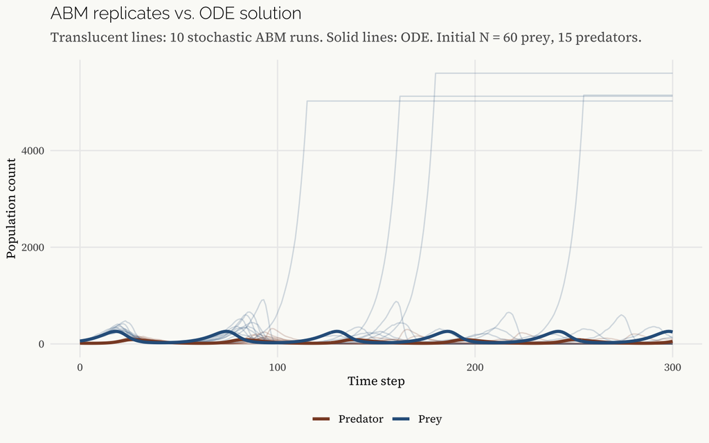

Ten stochastic ABM runs (translucent lines) overlaid on the corresponding mean-field ODE solution (solid lines). For a suitably scaled, density-dependent process with random mixing, the normalized ABM trajectory approaches the ODE over finite time horizons as population size grows.

```r
# Run 10 ABM replications with a large population
# Each run uses a different seed to show stochastic variation

set.seed(2025)  # master seed for reproducibility

n_reps   <- 10
T_run    <- 300   # matches slides; covers several LV cycles
n_prey0  <- 60
n_pred0  <- 15

abm_runs <- map_dfr(1:n_reps, function(rep) {
  run_lv_abm(T = T_run, n_prey = n_prey0, n_pred = n_pred0, seed = rep,
             p_birth = 0.15, p_kill = 0.00375, p_convert = 0.267,
             p_death = 0.10) %>%
    mutate(rep = rep)
})

# ODE solution for comparison — scaled to the same initial conditions
ode_state_ch2 <- c(N = n_prey0, P = n_pred0)
ode_out_ch2   <- ode(
  y     = ode_state_ch2,
  times = seq(0, T_run, by = 1),
  func  = lv_ode_ch2,
  parms = lv_params_ch2
)
ode_df_ch2 <- as_tibble(as.data.frame(ode_out_ch2)) %>%
  rename(t = time, prey = N, predator = P)

# Tidy ABM runs for plotting
abm_long <- abm_runs %>%
  pivot_longer(c(prey, predator), names_to = "species", values_to = "count")

ode_long <- ode_df_ch2 %>%
  pivot_longer(c(prey, predator), names_to = "species", values_to = "count")

ggplot() +
  geom_line(
    data = abm_long,
    aes(x = t, y = count, color = species, group = interaction(rep, species)),
    alpha = 0.2, linewidth = 0.5
  ) +
  geom_line(
    data = ode_long,
    aes(x = t, y = count, color = species),
    linewidth = 1.2
  ) +
  scale_color_manual(
    values = palette_ch2[c("prey", "predator")],
    labels = c("prey" = "Prey", "predator" = "Predator")
  ) +
  labs(
    title    = "ABM replicates vs. ODE solution",
    subtitle = "Translucent lines: 10 stochastic ABM runs. Solid lines: ODE. Initial N = 60 prey, 15 predators.",
    x        = "Time step",
    y        = "Population count",
    color    = NULL
  )
```

Now reduce the population.

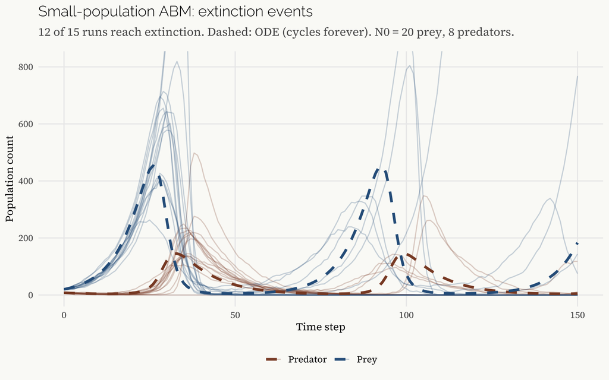

Finite-time extinction in a small stochastic population. The deterministic ODE remains positive and orbits indefinitely from the same positive initial condition; ABM runs can hit zero, after which extinction is absorbing.

```r
# Small-population ABM: extinction is possible
set.seed(2025)  # reproducibility

n_reps_small <- 15
T_small      <- 150
n_prey_small <- 20   # small enough for demographic stochasticity to matter
n_pred_small <- 8

abm_small <- map_dfr(1:n_reps_small, function(rep) {
  run_lv_abm(
    T         = T_small,
    n_prey    = n_prey_small,
    n_pred    = n_pred_small,
    seed      = rep + 100,
    p_birth   = 0.15,
    p_kill    = 0.00375,
    p_convert = 0.267,
    p_death   = 0.10
  ) %>%
    mutate(rep = rep)
})

# ODE solution with the same (small) initial conditions
ode_small_state <- c(N = n_prey_small, P = n_pred_small)
ode_small_out   <- ode(
  y     = ode_small_state,
  times = seq(0, T_small, by = 1),
  func  = lv_ode_ch2,
  parms = lv_params_ch2
)
ode_small_df <- as_tibble(as.data.frame(ode_small_out)) %>%
  rename(t = time, prey = N, predator = P) %>%
  pivot_longer(c(prey, predator), names_to = "species", values_to = "count")

abm_small_long <- abm_small %>%
  pivot_longer(c(prey, predator), names_to = "species", values_to = "count")

# Count extinctions
extinction_count <- abm_small %>%
  group_by(rep) %>%
  summarise(
    prey_extinct     = any(prey == 0),
    predator_extinct = any(predator == 0)
  ) %>%
  summarise(
    n_any_extinct = sum(prey_extinct | predator_extinct)
  ) %>%
  pull(n_any_extinct)

# Set ylim just above the peaks of the well-behaved (periodic/extinct) runs.
# Diverging runs exceed this limit and are clipped; noted in the text below.
run_peaks <- abm_small_long %>%
  group_by(rep, species) %>%
  summarise(peak = max(count), .groups = "drop")
ylim_cap <- quantile(run_peaks$peak, 0.80) * 1.05

ggplot() +
  geom_line(
    data = abm_small_long,
    aes(x = t, y = count, color = species, group = interaction(rep, species)),
    alpha = 0.25, linewidth = 0.5
  ) +
  geom_line(
    data = ode_small_df,
    aes(x = t, y = count, color = species),
    linewidth = 1.2, linetype = "dashed"
  ) +
  scale_color_manual(
    values = palette_ch2[c("prey", "predator")],
    labels = c("prey" = "Prey", "predator" = "Predator")
  ) +
  coord_cartesian(ylim = c(0, ylim_cap)) +
  labs(
    title    = "Small-population ABM: extinction events",
    subtitle = paste0(
      extinction_count, " of ", n_reps_small,
      " runs reach extinction. Dashed: ODE (cycles forever). N0 = ",
      n_prey_small, " prey, ", n_pred_small, " predators."
    ),
    x     = "Time step",
    y     = "Population count",
    color = NULL
  )
```

The ODE orbits forever. For the Lotka-Volterra system with positive initial conditions, the positive quadrant is invariant: trajectories do not reach zero. The ABM can fall to zero because it represents discrete individuals: when the last prey individual dies, the population is extinguished, and that is a state from which there is no return. The phenomenon of extinction — one of the most consequential events in population biology — has no representation in the ODE’s state space: the ODE’s variables are real-valued and positive, and zero is not an absorbing state. (Lande 1993)

A minority of runs go the other direction entirely: demographic stochasticity amplifies a favorable initial sequence and the population explodes before the predator response can stabilize it. Those runs exceed the figure’s y-axis limit and are clipped — the upper face of small-number noise, and equally outside the ODE’s representational range.

## 2.3 An Agent-Based SIR

### 2.3.1 Random Mixing

To begin with as simpler a departure from the ODE as possible, suppose each infectious agent contacts random members of the population at each step — the contact structure is still fully mixed, still mass-action — but the population is now a collection of persons rather than a continuous quantity. The mean-field assumption survives the move to discrete individuals. The point is to show that the individual-based model recovers the ODE when the assumption holds, then ask what happens when it doesn’t. So far, only the implementation has changed.

```r
# Agent-based SIR with random mixing
# Each infectious agent contacts a random subset of the population at each step

run_sir_abm_random <- function(N = 500, I0 = 5, p_infect = 0.05,
                                p_recover = 0.1, contacts_per_step = 5,
                                T = 150, seed = 42) {
  set.seed(seed)  # seed for reproducibility; change to explore variation

  agents <- tibble(
    id    = seq_len(N),
    state = c(rep("I", I0), rep("S", N - I0))
  )

  map_dfr(0:T, function(tt) {
    if (tt > 0) {
      infected_ids <- agents$id[agents$state == "I"]

      # Each infected agent makes contacts with random agents
      new_infected <- map(infected_ids, function(inf_id) {
        contacts           <- sample(setdiff(agents$id, inf_id),
                                     min(contacts_per_step, N - 1),
                                     replace = FALSE)
        suscept_contacts   <- contacts[agents$state[contacts] == "S"]
        if (length(suscept_contacts) == 0) return(integer(0))
        suscept_contacts[rbinom(length(suscept_contacts), 1, p_infect) == 1]
      }) %>%
        unlist() %>%
        unique()

      # Recovery
      recovering <- infected_ids[rbinom(length(infected_ids), 1, p_recover) == 1]

      agents <<- agents %>%
        mutate(state = case_when(
          id %in% new_infected & state == "S" ~ "I",
          id %in% recovering                  ~ "R",
          TRUE                                ~ state
        ))
    }

    tibble(
      t = tt,
      S = sum(agents$state == "S"),
      I = sum(agents$state == "I"),
      R = sum(agents$state == "R")
    )
  })
}
```

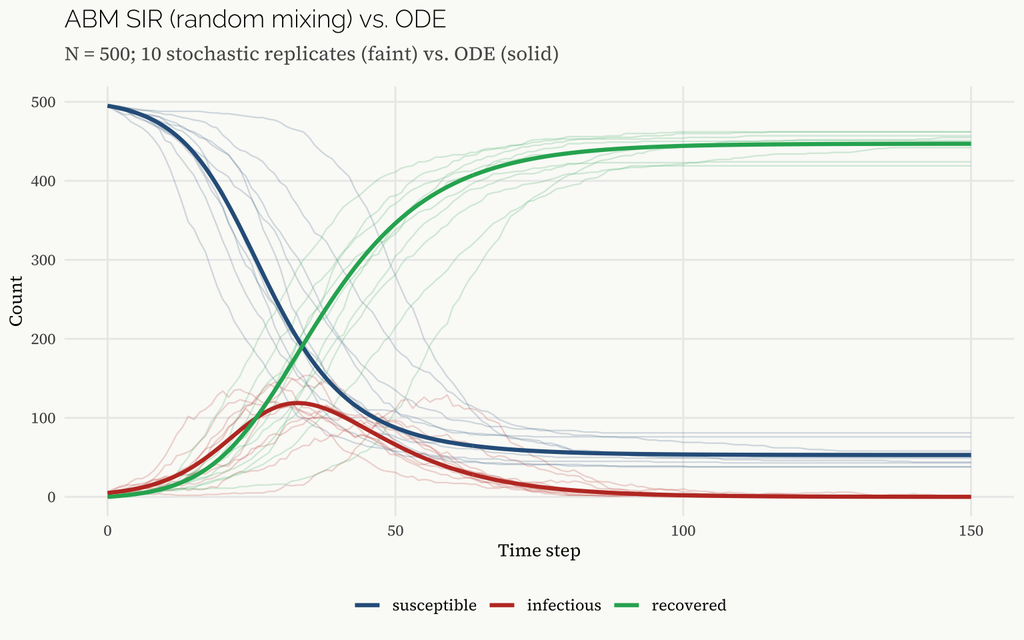

Agent-based SIR under random mixing (N = 500, 10 replicates shown as translucent lines) vs. ODE solution (solid lines). Convergence to the ODE is visible: the individual-based model recovers the mean-field dynamics when contacts are drawn uniformly from the population.

```r
set.seed(2025)

N_sir_compare <- 500
I0_compare    <- 5

# Run ABM replicates
sir_abm_runs <- map_dfr(1:10, function(rep) {
  run_sir_abm_random(
    N = N_sir_compare, I0 = I0_compare,
    p_infect = 0.05, p_recover = 0.1, contacts_per_step = 5,
    T = 150, seed = rep + 200
  ) %>%
    mutate(rep = rep)
})

# ODE comparison — match approximate R0
# R0 ≈ (p_infect * contacts_per_step) / p_recover  (rough approximation)
approx_R0  <- (0.05 * 5) / 0.1
beta_match <- approx_R0 * 0.1 / N_sir_compare

sir_ode_state <- c(S = N_sir_compare - I0_compare, I = I0_compare, R = 0)
sir_ode_out   <- ode(
  y     = sir_ode_state,
  times = seq(0, 150, by = 0.5),
  func  = sir_ode_ch2,
  parms = c(beta = beta_match, gamma = 0.1)
)
sir_ode_compare <- as_tibble(as.data.frame(sir_ode_out)) %>%
  rename(t = time)

sir_abm_long <- sir_abm_runs %>%
  pivot_longer(c(S, I, R), names_to = "compartment", values_to = "count") %>%
  mutate(compartment = factor(compartment, levels = c("S", "I", "R"),
                              labels = c("susceptible", "infectious", "recovered")))

sir_ode_long <- sir_ode_compare %>%
  pivot_longer(c(S, I, R), names_to = "compartment", values_to = "count") %>%
  mutate(compartment = factor(compartment, levels = c("S", "I", "R"),
                              labels = c("susceptible", "infectious", "recovered")))

ggplot() +
  geom_line(
    data = sir_abm_long,
    aes(x = t, y = count, color = compartment,
        group = interaction(rep, compartment)),
    alpha = 0.2, linewidth = 0.4
  ) +
  geom_line(
    data = sir_ode_long,
    aes(x = t, y = count, color = compartment),
    linewidth = 1.1
  ) +
  scale_color_manual(
    values = palette_ch2[c("susceptible", "infectious", "recovered")]
  ) +
  labs(
    title    = "ABM SIR (random mixing) vs. ODE",
    subtitle = paste0("N = ", N_sir_compare, "; 10 stochastic replicates (faint) vs. ODE (solid)"),
    x        = "Time step",
    y        = "Count",
    color    = NULL
  )
```

### 2.3.2 Network SIR

Now suppose the agents are connected in a social network; families, schools, workplaces etc. We will consider two network models.

**Activity — Model Autopsy (15 minutes)**

For each question below, name the distinction the model must retain, decide whether a mean-field SIR can answer it, and identify any missing state or structure.

1. What will the epidemic peak be?
2. Who should receive a limited vaccine supply?
3. Does clustering protect part of the population?
4. How variable are outcomes across outbreaks?

Separate a question the model answers poorly from one it cannot express. Prepare one case to defend in a sentence.

```r
set.seed(2025)  # reproducibility for network generation

N_net   <- 500
avg_deg <- 6   # target mean degree

# Erdős-Rényi: edges placed independently with fixed probability
# Mean degree = p * (N - 1) ≈ avg_deg
g_er <- igraph::erdos.renyi.game(N_net, p = avg_deg / (N_net - 1))

# Barabási-Albert: preferential attachment produces a heavy-tailed degree distribution
# m = edges added per new node; mean degree ≈ 2m
g_ba <- igraph::sample_pa(N_net, m = avg_deg / 2, directed = FALSE)

# Verify mean degrees are comparable
mean_deg_er <- mean(igraph::degree(g_er))
mean_deg_ba <- mean(igraph::degree(g_ba))
```

These networks have comparable mean degree — each individual is connected to roughly the same number of others on average. What differs is the distribution of that degree. The Erdős-Rényi graph is the random graph: each pair of nodes is connected independently with fixed probability, and the degree distribution is approximately Poisson (Erdős and Rényi 1959, 1960). In a Poisson degree distribution, most nodes have degree close to the mean; there are no hubs. The Barabási-Albert graph grows by preferential attachment — new nodes attach to existing nodes in proportion to their current degree, and rich nodes get richer (Barabási and Albert 1999). The result is a scale-free degree distribution: most nodes have few connections, but a small number of hubs have very many. These hubs do not appear in an Erdős-Rényi network with the same mean degree.

```r
# Network SIR: infection spreads along edges
# Nodes are infected by each infected neighbor independently with probability p_infect

run_network_sir <- function(g, I0 = 5, p_infect = 0.05, p_recover = 0.1,
                              T = 100, seed = 42) {
  set.seed(seed)  # seed for reproducibility

  N     <- igraph::vcount(g)
  state <- rep("S", N)
  state[sample(N, I0)] <- "I"

  # Precompute adjacency list for fast neighbor lookup
  adj <- igraph::as_adj_list(g)

  map_dfr(0:T, function(tt) {
    if (tt > 0) {
      infected_ids <- which(state == "I")

      # Collect newly infected nodes
      new_I <- integer(0)
      for (v in infected_ids) {
        nbrs        <- as.integer(adj[[v]])
        suscept_nbrs <- nbrs[state[nbrs] == "S"]
        if (length(suscept_nbrs) > 0) {
          newly  <- suscept_nbrs[rbinom(length(suscept_nbrs), 1, p_infect) == 1]
          new_I  <- c(new_I, newly)
        }
      }

      # Recovery
      recovering <- infected_ids[rbinom(length(infected_ids), 1, p_recover) == 1]

      # Update states — order matters: infections before recoveries
      state[unique(new_I)] <<- "I"
      state[recovering]    <<- "R"
    }

    tibble(
      t = tt,
      S = sum(state == "S"),
      I = sum(state == "I"),
      R = sum(state == "R")
    )
  })
}
```

```r
set.seed(2025)

# Run SIR on both networks with identical parameters
sir_er <- run_network_sir(g_er, I0 = 5, p_infect = 0.05, p_recover = 0.1,
                           T = 100, seed = 301)
sir_ba <- run_network_sir(g_ba, I0 = 5, p_infect = 0.05, p_recover = 0.1,
                           T = 100, seed = 302)

sir_network_df <- bind_rows(
  mutate(sir_er, network = "Erdős-Rényi"),
  mutate(sir_ba, network = "Barabási-Albert")
)
```

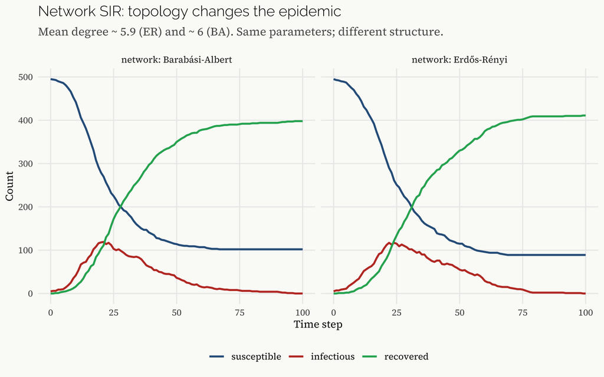

```r
sir_network_long <- sir_network_df %>%
  pivot_longer(c(S, I, R), names_to = "compartment", values_to = "count") %>%
  mutate(
    compartment = factor(compartment, levels = c("S", "I", "R"),
                         labels = c("susceptible", "infectious", "recovered"))
  )

ggplot(sir_network_long, aes(x = t, y = count, color = compartment)) +
  geom_line(linewidth = 0.9) +
  facet_wrap(~ network, labeller = label_both) +
  scale_color_manual(values = palette_ch2[c("susceptible", "infectious", "recovered")]) +
  labs(
    title    = "Network SIR: topology changes the epidemic",
    subtitle = paste0("Mean degree ~ ", round(mean_deg_er, 1),
                      " (ER) and ~ ", round(mean_deg_ba, 1), " (BA). Same parameters; different structure."),
    x        = "Time step",
    y        = "Count",
    color    = NULL
  )
```

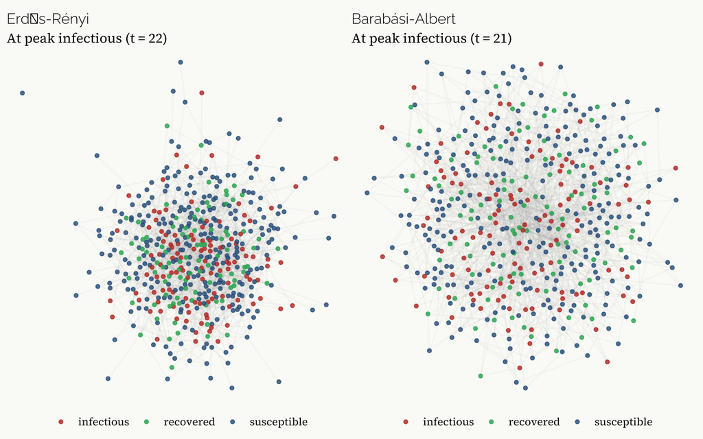

Contact network structures at the peak of the epidemic. Node color indicates compartment status: blue = susceptible, red = infectious, green = recovered. Left: Erdős-Rényi graph, with roughly uniform degree distribution. Right: Barabási-Albert graph, with visible hub nodes carrying many connections. The hub structure changes the epidemic’s geometry.

```r
set.seed(2025)

# Find peak time for each network
t_peak_er <- sir_er %>% filter(I == max(I)) %>% slice(1) %>% pull(t)
t_peak_ba <- sir_ba %>% filter(I == max(I)) %>% slice(1) %>% pull(t)

# Helper: get node states at a given time step
get_states_at_t <- function(g, t_target, I0 = 5, p_infect = 0.05,
                              p_recover = 0.1, seed = 42) {
  set.seed(seed)
  N     <- igraph::vcount(g)
  state <- rep("S", N)
  state[sample(N, I0)] <- "I"
  adj   <- igraph::as_adj_list(g)

  for (tt in seq_len(t_target)) {
    infected_ids <- which(state == "I")
    new_I <- integer(0)
    for (v in infected_ids) {
      nbrs         <- as.integer(adj[[v]])
      suscept_nbrs <- nbrs[state[nbrs] == "S"]
      if (length(suscept_nbrs) > 0) {
        newly <- suscept_nbrs[rbinom(length(suscept_nbrs), 1, p_infect) == 1]
        new_I <- c(new_I, newly)
      }
    }
    recovering       <- infected_ids[rbinom(length(infected_ids), 1, p_recover) == 1]
    state[unique(new_I)] <- "I"
    state[recovering]    <- "R"
  }
  state
}

states_er <- get_states_at_t(g_er, t_peak_er, seed = 301)
states_ba <- get_states_at_t(g_ba, t_peak_ba, seed = 302)

# Tidygraph objects for ggraph
tg_er <- as_tbl_graph(g_er) %>%
  mutate(compartment = states_er,
         network     = "Erdős-Rényi")

tg_ba <- as_tbl_graph(g_ba) %>%
  mutate(compartment = states_ba,
         network     = "Barabási-Albert")

plot_network <- function(tg, title_str, t_peak) {
  ggraph(tg, layout = "fr") +
    geom_edge_link(alpha = 0.05, color = "#888888") +
    geom_node_point(aes(color = compartment), size = 1.2, alpha = 0.8) +
    scale_color_manual(
      values = c(S = "#2D5F8A", I = "#C0392B", R = "#27AE60"),
      labels = c(S = "susceptible", I = "infectious", R = "recovered"),
      name   = NULL
    ) +
    labs(title = title_str,
         subtitle = paste0("At peak infectious (t = ", t_peak, ")")) +
    theme_void(base_family = "Source Serif 4") +
    theme(legend.position = "bottom",
          plot.title = element_text(family = "Raleway", size = 12),
          plot.background = element_rect(fill = "#FAFAF7", color = NA))
}

p_er_net <- plot_network(tg_er, "Erdős-Rényi", t_peak_er)
p_ba_net <- plot_network(tg_ba, "Barabási-Albert", t_peak_ba)

p_er_net + p_ba_net
```

The same $\beta$. The same $\gamma$ and a different outcome.

The ODE has no state variable or parameter representing contact network topology (Pastor-Satorras and Vespignani 2001). No values of $\beta$ and $\gamma$ reproduce the difference between these two epidemics — the model cannot distinguish Erdős-Rényi from Barabási-Albert contact structure except through changes in aggregate rates, and the aggregate rates are the same. In the model’s terms, networks have no place to enter.

## 2.4 The Reduction Principle

The reduction principle is that familiar ODE models can be recovered as limits of appropriately constructed agent-based models. Agent homogeneity and mean-field contact structure are two central structural restrictions. Write each agent’s property vector as $\theta_i = \theta_0 + \varepsilon_i$, and set $\varepsilon_i = 0$ for all $i$ — every agent is identical to the model’s central reference parameter $\theta_0$. Then write the weighted contact matrix as $W = \bar{W} + \Delta W$, where $\bar{W}_{ij} = 1/(n-1)$ for $i \neq j$ and $\bar{W}_{ii} = 0$, and set $\Delta W = 0$. Under exchangeability and a fixed row total, $\bar W$ is the uniform contact baseline (Jaynes 1957). A large-population ODE limit additionally requires compatible event-rate scaling and regularity conditions (Kurtz 1970, 1978). Population size alone says nothing about contact structure: increasing a lattice, household network, or scale-free network need not produce the well-mixed ODE.

The demonstration is direct. Fix a Barabási-Albert contact structure and scale up the population, holding all rate parameters constant. As $N$ grows, demographic stochasticity shrinks and the stochastic replicates collapse toward a single curve. That curve is not the ODE.

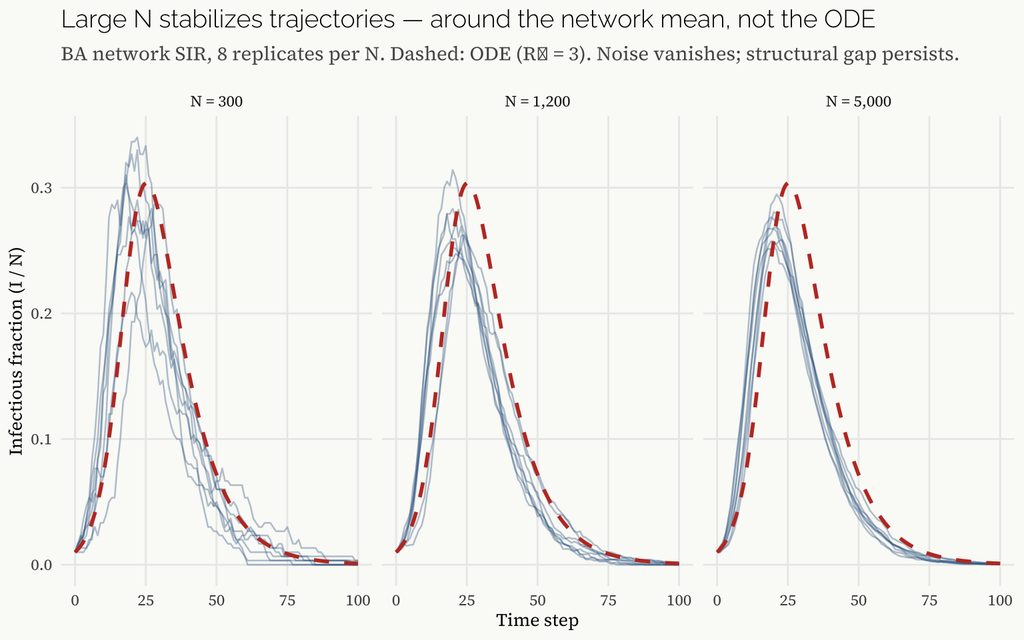

The law of large numbers operating on a structured contact network. Each panel shows the infectious fraction $I(t)/N$ for eight stochastic replicates (blue) on a Barabási-Albert scale-free network at three population sizes. As $N$ increases, stochastic variation contracts and the replicates collapse toward a single trajectory. The ODE (dashed red) does not move: the converging trajectories approach the structured-network mean, not the mean-field limit. Large $N$ buys variance reduction. It does not correct structural bias.

```r
# LLN demonstration on a structured (BA) contact network.
# Population size increases; contact structure type is held fixed.
# Each BA network is generated fresh at each N with the same preferential-attachment
# rule (m = avg_deg/2), so the contact structure scales with the population
# but remains scale-free at every N.
# This chunk may take a minute on first render; results are cached.

set.seed(2025)

N_values_lln  <- c(300L, 1200L, 5000L)
n_reps_lln    <- 8L
avg_deg_lln   <- 6L
I0_frac_lln   <- 0.01   # 1% initial infected, constant across N

run_ba_sir_lln <- function(N, I0_frac = 0.01, p_infect = 0.05, p_recover = 0.1,
                            T = 100, seed = 42) {
  set.seed(seed)
  I0    <- max(1L, round(I0_frac * N))
  g     <- igraph::sample_pa(N, m = avg_deg_lln %/% 2L, directed = FALSE)
  state <- rep("S", N)
  state[sample(N, I0)] <- "I"
  adj   <- igraph::as_adj_list(g)

  map_dfr(0:T, function(tt) {
    if (tt > 0) {
      infected_ids <- which(state == "I")
      new_I <- integer(0)
      for (v in infected_ids) {
        nbrs         <- as.integer(adj[[v]])
        suscept_nbrs <- nbrs[state[nbrs] == "S"]
        if (length(suscept_nbrs) > 0) {
          newly  <- suscept_nbrs[rbinom(length(suscept_nbrs), 1, p_infect) == 1]
          new_I  <- c(new_I, newly)
        }
      }
      recovering           <- infected_ids[rbinom(length(infected_ids), 1, p_recover) == 1]
      state[unique(new_I)] <<- "I"
      state[recovering]    <<- "R"
    }
    tibble(t = tt, I_frac = sum(state == "I") / N)
  })
}

lln_demo_runs <- map_dfr(N_values_lln, function(n_val) {
  map_dfr(seq_len(n_reps_lln), function(r) {
    run_ba_sir_lln(N = n_val, I0_frac = I0_frac_lln,
                   seed = 600L + n_val + r, T = 100) %>%
      mutate(N = n_val, rep = r)
  })
}) %>%
  mutate(N_label = factor(paste0("N = ", scales::comma(N)),
                          levels = paste0("N = ", scales::comma(sort(N_values_lln)))))

# ODE comparison in fraction formulation — does not depend on N.
# R0 = p_infect * avg_deg / p_recover = 0.05 * 6 / 0.1 = 3.
# Discrete-to-continuous correction: gamma = -log(1 - p_recover); beta = R0 * gamma.
gamma_lln <- -log(1 - 0.1)
beta_lln  <- 3 * gamma_lln

sir_frac_ode <- function(t, state, params) {
  with(as.list(c(state, params)), {
    dS <- -beta * S * I
    dI <-  beta * S * I - gamma * I
    dR <-  gamma * I
    list(c(dS, dI, dR))
  })
}

ode_lln_df <- as_tibble(as.data.frame(
  ode(y     = c(S = 1 - I0_frac_lln, I = I0_frac_lln, R = 0),
      times = seq(0, 100, by = 0.5),
      func  = sir_frac_ode,
      parms = c(beta = beta_lln, gamma = gamma_lln))
)) %>% rename(t = time)

ggplot() +
  geom_line(
    data = lln_demo_runs,
    aes(x = t, y = I_frac, group = interaction(N, rep)),
    alpha = 0.35, linewidth = 0.45, color = "#2D5F8A"
  ) +
  geom_line(
    data = ode_lln_df,
    aes(x = t, y = I),
    linetype = "dashed", color = "#C0392B", linewidth = 1.0
  ) +
  facet_wrap(~ N_label, nrow = 1) +
  labs(
    title    = "Large N stabilizes trajectories — around the network mean, not the ODE",
    subtitle = paste0("BA network SIR, ", n_reps_lln, " replicates per N. ",
                      "Dashed: ODE (R\u2080 = 3). Noise vanishes; structural gap persists."),
    x        = "Time step",
    y        = "Infectious fraction (I / N)"
  )
```

The law of large numbers is doing its job. The variance is contracting with $N$ exactly as the theory requires. What it is not doing is closing the gap between the structured-network trajectory and the mean-field limit. The dashed ODE line sits persistently apart. The gap does not narrow with more replicates, and it does not narrow with larger $N$. It is the structural consequence of the contact network topology — and it persists because the network persists.

When data are recorded at coarse temporal resolution — weekly, quarterly, annually — the sequence of individual interactions within each observation interval is unobservable. Contacts that occurred in a specific order between specific agents are treated as simultaneous. Under exchangeability and a fixed contact total, uniform mixing is a symmetry-based baseline for this unresolved structure (Jaynes 1957). It is not uniquely least-informative without those constraints. Structured models can still be compared when they imply distinguishable aggregate behavior at the observed frequency; otherwise the observation design does not identify the within-interval pairing and order. This resembles a sampling limit, though the Nyquist theorem applies specifically to regularly sampled, band-limited signals (1928). The resulting bias is the price of statistical stability under the chosen baseline.

The data constraint and the structural claim are not the same argument. The data constraint says: at this observation frequency, the data cannot distinguish mean-field from structured interaction. The structural claim says: the phenomenon’s natural time scale is slow enough that interactions genuinely randomize between observations — that $\Delta W \approx 0$ is warranted by the system’s dynamics, not merely forced by the data. The first is imposed by the observation design. The second is a philosophical contention about the phenomenon. A researcher with high-frequency contact data who nevertheless invokes the mean-field is making the structural claim. A researcher with only low-frequency data who invokes it may be making either — and should say which, because the two have different implications for what could, in principle, falsify the model.

One formal version of this principle appears in the theory of density-dependent Markov chains (Kurtz 1970, 1978): as $n \to \infty$, as $\varepsilon_i \to 0$ for all $i$, and as $\Delta W \to 0$, the ABM converges in distribution to the ODE. This is a conditional result: it says what the ABM becomes when both restrictions are imposed simultaneously. In that limiting case, the ODE is not an approximation to the ABM but the reduced form obtained after imposing the relevant restrictions. The question is always whether those restrictions are warranted for the phenomenon at hand.

The ABM is the richer language; the ODE is the sublanguage recovered under homogeneity and mean-field contact. They are related by named restrictions rather than by a vague appeal to complexity or realism. The ODEs are a singularity with the broader family. The choice between them is a question about which restrictions are warranted for the phenomenon and the data.

The ABM has more nominal parameters than the Lotka-Volterra ODE: $p_\text{birth}$, $p_\text{eat}$, $p_\text{death}$, the population size, the pairing mechanism. The ODE has four: $\alpha$, $\beta$, $\delta$, $\gamma$. A regression with a thousand predictors may have a sparse solution concentrated on ten — nominal and effective dimensionality are different things. The scientist who counts predictors before asking whether the signal is sparse has the analysis backwards. The critic who counts ABM parameters before asking how many degrees of freedom the dynamics of interest actually require has made the same mistake. Many regions of the ABM’s parameter space produce qualitatively identical behavior — cycling statistically indistinguishable from the ODE output. The consequential structure — the boundary between cycling and extinction, the dependence of extinction probability on population size — is low-dimensional relative to the nominal parameter count. The ODE is the ABM under maximal regularization of both $\varepsilon_i$ and $\Delta W$: the restriction that produces its analytical tractability is the same restriction that removes certain phenomena from its vocabulary, and no amount of careful parameter estimation recovers what that regularization has discarded.

Parameterize the contact matrix as a mixture: with probability $p$, each infected agent contacts a random individual drawn uniformly from the population; with probability $1-p$, it contacts a neighbor from the scale-free network. At $p = 1$, $\Delta W = 0$ exactly — the mean-field. At $p = 0$, $\Delta W$ carries the full network structure. Every intermediate value is a point on the regularization path.

Each curve below is the mean of fifteen stochastic runs. The ODE is parameterized to match: $\gamma = -\log(1 - p_\text{recover})$ converts the ABM’s geometric per-step recovery to its continuous-time equivalent, and $\beta$ is scaled to preserve $\mathcal{R}_0 = 3$ under that corrected $\gamma$. A residual gap between the $p = 1$ mean and the ODE dashed line is unavoidable — the ABM operates in discrete time with step size 1, while the ODE is continuous; at unit step size, higher-order discretization terms remain. The gap closes as the step size shrinks. It does not close with more data, more replicates, or better parameter tuning. It is not a calibration failure. It is the boundary between the two languages.

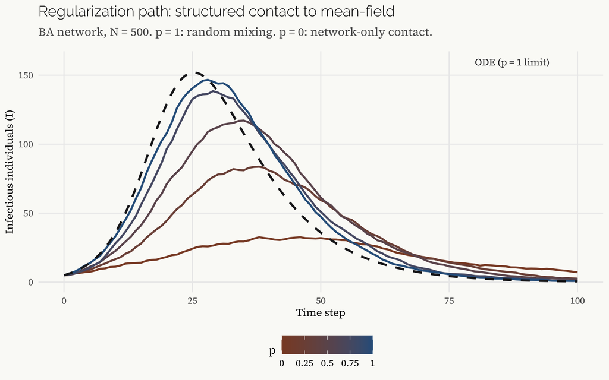

The regularization path from structured network contact ($p = 0$, full $\Delta W$) to random mixing ($p = 1$, $\Delta W = 0$). Each curve shows $I(t)$ for a different value of the mixing probability on the Barabási-Albert network. The ODE (dashed) is the $p = 1$ limit. Dialing $p$ from 0 to 1 shrinks $\Delta W$ toward zero: the regularization path between the structured ABM and the differential equation.

```r
set.seed(2025)  # reproducibility

# Mixed contact SIR: each infected agent makes contacts_per_step contacts per step.
# Each contact is drawn from the global population with probability p_random,
# or from the network neighborhood with probability 1 - p_random.
# Total contact rate is held constant across p_random values, so differences
# in dynamics are purely structural — a change in Delta W, not in contact rate.
run_mixed_sir <- function(g, p_random = 0.5, I0 = 5, p_infect = 0.05,
                           p_recover = 0.1, contacts_per_step = 6,
                           T = 100, seed = 42) {
  set.seed(seed)
  N     <- igraph::vcount(g)
  state <- rep("S", N)
  state[sample(N, I0)] <- "I"
  adj   <- igraph::as_adj_list(g)

  map_dfr(0:T, function(tt) {
    if (tt > 0) {
      infected_ids <- which(state == "I")
      new_I <- integer(0)

      for (v in infected_ids) {
        # Binomial split: n_rand contacts from global pool, remainder from network
        n_rand <- rbinom(1, contacts_per_step, p_random)
        n_net  <- contacts_per_step - n_rand

        contacts <- integer(0)
        if (n_rand > 0)
          contacts <- c(contacts,
                        sample(setdiff(seq_len(N), v), min(n_rand, N - 1),
                               replace = FALSE))
        if (n_net > 0) {
          nbrs <- as.integer(adj[[v]])
          if (length(nbrs) > 0)
            contacts <- c(contacts,
                          sample(nbrs, min(n_net, length(nbrs)), replace = FALSE))
        }

        suscept <- contacts[state[contacts] == "S"]
        if (length(suscept) > 0)
          new_I <- c(new_I, suscept[rbinom(length(suscept), 1, p_infect) == 1])
      }

      recovering           <- infected_ids[rbinom(length(infected_ids), 1, p_recover) == 1]
      state[unique(new_I)] <<- "I"
      state[recovering]    <<- "R"
    }
    tibble(t = tt, S = sum(state == "S"), I = sum(state == "I"), R = sum(state == "R"))
  })
}

# Five points on the regularization path — 15 replicates each, averaged to
# reduce stochastic noise so the p=1 mean converges visually to the ODE
p_values <- c(0, 0.25, 0.5, 0.75, 1.0)
n_reps   <- 15

mixed_runs <- map_dfr(seq_along(p_values), function(i) {
  map_dfr(seq_len(n_reps), function(r) {
    run_mixed_sir(g_ba, p_random = p_values[i], I0 = 5,
                  p_infect = 0.05, p_recover = 0.1, contacts_per_step = avg_deg,
                  T = 100, seed = 400 + (i - 1) * n_reps + r) %>%
      mutate(p_random = p_values[i])
  })
}) %>%
  group_by(p_random, t) %>%
  summarise(I = mean(I), .groups = "drop")

# ODE overlay. Discrete-to-continuous conversion must correct BOTH parameters
# jointly to preserve R0. The discrete ABM has R0_disc = p_infect * c / p_recover = 3.
# The exact continuous equivalents are:
#   gamma_cont = -log(1 - p_recover)              # geometric → exponential recovery
#   beta_cont  = R0_disc * gamma_cont / N         # preserves R0 = 3 in continuous ODE
# Using gamma=0.1 directly (without the correction) lowers the effective continuous
# R0 to 2.85 and shifts the ODE peak down; correcting only gamma without adjusting
# beta has the opposite effect. Correcting both holds R0=3.
gamma_reg <- -log(1 - 0.1)
beta_reg  <- 3 * gamma_reg / N_net
ode_reg  <- as_tibble(as.data.frame(
  ode(y     = c(S = N_net - 5, I = 5, R = 0),
      times = seq(0, 100, by = 0.5),
      func  = sir_ode_ch2,
      parms = c(beta = beta_reg, gamma = gamma_reg))
)) %>% rename(t = time)

ggplot() +
  geom_line(
    data = mixed_runs,
    aes(x = t, y = I, color = p_random, group = p_random),
    linewidth = 0.9
  ) +
  geom_line(
    data = ode_reg,
    aes(x = t, y = I),
    linetype = "dashed", color = "#1C1C1E", linewidth = 1.0
  ) +
  scale_color_gradient(
    low    = "#8A4A2D",
    high   = "#2D5F8A",
    name   = expression(p),
    breaks = p_values,
    labels = p_values
  ) +
  annotate("text", x = 80, y = max(ode_reg$I) * 1.05,
           label = "ODE (p = 1 limit)", family = "Source Serif 4",
           size = 3.2, color = "#1C1C1E", hjust = 0) +
  labs(
    title    = "Regularization path: structured contact to mean-field",
    subtitle = paste0("BA network, N = ", N_net,
                      ". p = 1: random mixing. p = 0: network-only contact."),
    x        = "Time step",
    y        = "Infectious individuals (I)"
  )
```

## 2.5 Wolf-Sheep Predation and the Absorbing Boundary

> **Note for readers:** This section is not walked through in the live session. The pre-rendered animation and figures are shown as demonstration. The full implementation is distributed in `slides/render_spatial_anim.R` and `slides/render_parallel_runs.R`.

The predator-prey models introduced thus far preserve the mean-field assumption in one way: agents move randomly, and a wolf encounters any sheep with equal probability regardless of position. The spatial extension removes that last refuge of the ODE. A wolf eats a sheep only if they occupy the same cell on a $51 \times 51$ toroidal grid. Contact is local. Neighborhoods exist.

The model is a direct R translation of Wilensky’s (2005) Wolf-Sheep Predation in NetLogo — a model with a thirty-year history of classroom use in complex systems courses. The rules are spare:

- Each tick, all agents perform a random walk to an adjacent cell.
- Wolves lose one energy unit per tick.
- A wolf on the same cell as one or more sheep grabs one at random, gaining `wolf_gain_food` energy. Each sheep can be eaten by at most one wolf per tick.
- Any agent whose energy falls below zero dies.
- Each agent reproduces with a small per-tick probability, halving its energy and placing an offspring in an adjacent cell.

The key line — the one that changes everything — is the spatial restriction on predation. In the random-mixing ABM, a wolf samples from the full population. Here it samples from `sheep-here`: sheep sharing its current cell. The mean-field assumption is gone.

```r
# Wolf-Sheep Predation — R translation of Wilensky (2005) NetLogo model
# Full implementation: slides/render_spatial_anim.R
# set.seed(2025)

G             <- 51L   # 51x51 toroidal grid (NetLogo default)
wolf_gain_food <- 20L
sheep_reproduce <- 4.0   # % per tick
wolf_reproduce  <- 5.0   # % per tick

wrap <- function(v, g) ((v - 1L) %% g) + 1L

random_walk <- function(x, y, g) {
  dx <- sample(-1L:1L, length(x), replace = TRUE)
  dy <- sample(-1L:1L, length(y), replace = TRUE)
  list(x = wrap(x + dx, g), y = wrap(y + dy, g))
}

# Wolves eat one random sheep per cell; each sheep eaten at most once per tick
eats <- wolf_df |>
  left_join(sheep_df, by = c("x", "y"), relationship = "many-to-many") |>
  group_by(wolf_id)  |> slice_sample(n = 1L) |> ungroup() |>
  group_by(sheep_id) |> slice_sample(n = 1L) |> ungroup()
```

The animation below shows every tick of a single run from $t = 0$ to extinction at $t = 146$. Sheep (blue) expand freely in the early ticks. Wolves (red) follow with a lag, cluster where sheep are dense, and overshoot. By $t = 110$ the wolves number 544; only 195 sheep remain. The prey base collapses. The wolves, now hunting an empty grid, starve.

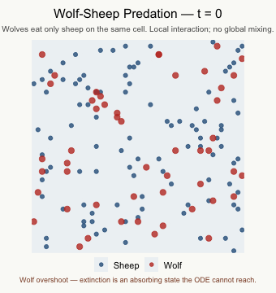

Wolf-Sheep Predation on a 51×51 toroidal grid. Each frame is one tick; the animation runs from t = 0 to extinction at t = 146. Sheep: blue. Wolves: red.

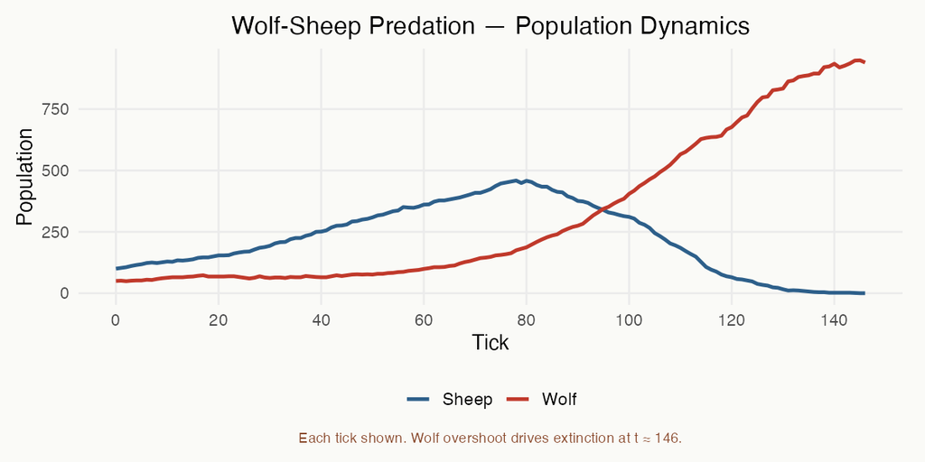

The ODE with equivalent parameters cycles forever. The ABM does not necessarily or even usually. This is not a quantitative discrepancy — not a matter of the ABM predicting a slightly different amplitude or period. The finite stochastic population hits zero in finite time, after which extinction is absorbing. The deterministic ODE does represent zero as an invariant boundary, but a trajectory starting from positive populations does not hit that boundary in finite time. The distinction is between a state absent from the deterministic trajectory and a state absent from the equations themselves.

### 2.5.1 The Stabilizing Role of Grass

One is entitled to ask whether extinction is the inevitable outcome or merely the typical one — and whether the ODE’s cycling behavior could emerge from the ABM under different conditions. Both questions have the same answer: add grass.

The grass variant of the model (Wilensky 2005) introduces a third trophic level. Each grid cell is either green (grazeable) or brown (exhausted). A sheep on a green cell gains `sheep_gain_from_food` energy units, turning the cell brown. Brown cells regrow to green after `grass_regrowth_time` ticks. Sheep now lose one energy unit per tick regardless of predation — they must eat to live.

```r
# Grass extension — slides/render_parallel_runs.R
sheep_gain_from_food <- 4L
grass_regrowth_time  <- 30L

# patch_countdown is a flat integer vector of length G*G.
# 0 = green (grazeable); >0 = brown, counting down to regrowth.
cell_idx <- function(x, y, g) (x - 1L) * g + y

# Each tick: sheep on green patches eat; patch turns brown.
s_cells  <- cell_idx(agents$x[sheep_idx], agents$y[sheep_idx], G)
is_green <- patch_countdown[s_cells] == 0L
eat_df   <- tibble(row = sheep_idx[is_green], cell = s_cells[is_green]) |>
  group_by(cell) |> slice_sample(n = 1L) |> ungroup()
agents$energy[eat_df$row] <- agents$energy[eat_df$row] + sheep_gain_from_food
patch_countdown[eat_df$cell] <- grass_regrowth_time

# Each tick: brown patches count down.
patch_countdown[patch_countdown > 0L] <- patch_countdown[patch_countdown > 0L] - 1L
```

The mechanism is a resource cycle. When sheep are scarce, ungrazed patches recover. Recovered grass feeds surviving sheep. A recovering sheep population eventually supports a recovering wolf population. The feedback is negative at every link: high wolves $\rightarrow$ low sheep $\rightarrow$ grass recovery $\rightarrow$ sheep recovery $\rightarrow$ wolf recovery. This is the structure that generates sustained oscillation.

The question is empirical. Fifty independent runs of each variant, 300 ticks each:

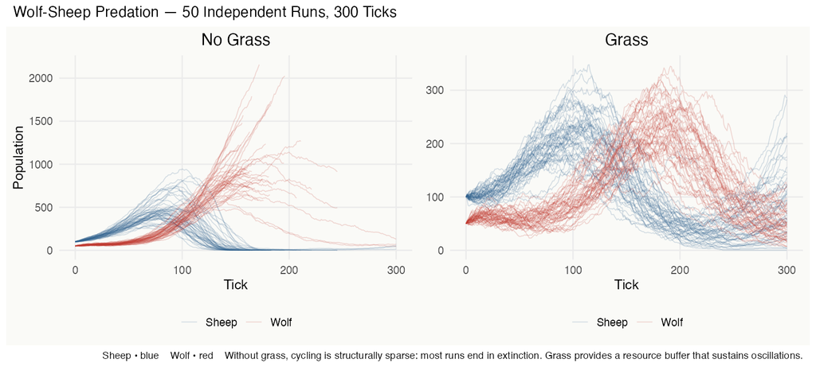

50 independent runs of the no-grass (left) and grass (right) Wolf-Sheep models, 300 ticks each. Without grass, 47 of 50 runs end in wolf overshoot and sheep extinction. With grass, 49 of 50 runs sustain both populations to t = 300.

Without grass, 47 of 50 runs end in wolf overshoot followed by sheep extinction. Cycling is the exception — three runs in fifty. With grass, 49 of 50 runs sustain both species to $t = 300$. The third trophic level converts extinction from the norm to the anomaly.

This result exposes something about the ODE that the ODE itself cannot reveal. The Lotka-Volterra prey equation is:

$$\frac{dN}{dt} = \alpha N - \beta
NP$$

The $\alpha N$ term says prey grow at a fixed per-capita rate, limited only by predation. This is not an approximation of a world with unlimited grass. It *is* a world with unlimited grass, encoded in functional form. The structural assumption is not stated.

The grass model makes the assumption explicit, then relaxes it. When grass is finite and regrows slowly, the prey’s recovery mechanism is bounded. Wolf overshoot can exhaust both prey and prey’s food supply simultaneously, leaving the system with no path back from low sheep numbers. The absorbing boundary becomes reachable.

The ODE cycles forever not because cyclic dynamics are general — the ABM shows they are not — but because inexhaustible prey resources are built into this model’s structure. In probabilistic terms, that fixed structural choice can be represented as a degenerate prior on the resource specification. It is a strong claim about the world, stated implicitly in the functional form; whether it is warranted depends on the system being modeled.

# 3 The Size of Firms, and What It Tells Us

```r
# Chapter 3 Setup
# Self-contained — does not depend on prior chapters.

library(tidyverse)
library(poweRlaw)
library(broom)
library(patchwork)

theme_set(
  theme_minimal(base_family = "Source Serif 4") +
    theme(
      plot.title       = element_text(family = "Raleway", face = "plain",
                                      size = 14, margin = margin(b = 8)),
      plot.subtitle    = element_text(family = "Source Serif 4", size = 11,
                                      color = "#555555", margin = margin(b = 12)),
      axis.title       = element_text(family = "Source Serif 4", size = 10),
      legend.position  = "bottom",
      panel.grid.minor = element_blank(),
      plot.background  = element_rect(fill = "#FAFAF7", color = NA)
    )
)
```

## 3.1 A Regularity That Refuses to Go Away

For the United States, across multiple years and definitions of firm size, the upper tail of the employment distribution is well described by a power law (Axtell 2001). Related heavy-tailed patterns have been documented in other economies, although estimated exponents and lower-tail behavior depend on the data and institutional definition of a firm. The US regularity alone is enough for the argument here: a model that replaces the distribution with a single reference value cannot reproduce its shape.

The dynamic range is the first clue that something unusual is happening. The largest firms in the US economy employ hundreds of thousands of workers; the smallest employ one. The ratio between these extremes is on the order of $10^5$ or $10^6$. A normal distribution cannot span that range without assigning negligible probability to the observed data. A log-normal can span this range and is a natural alternative. In many empirical firm-size datasets, however, the upper tail is better captured by a power-law specification, especially when the comparison is made on the complementary cumulative distribution over several orders of magnitude.

A power law distribution has the form $P(\text{size} \geq x) \propto x^{-(\alpha - 1)}$ for $x \geq x_\text{min}$. In logarithmic coordinates, the complementary cumulative distribution function is a straight line with slope $-(\alpha - 1)$. On a linear scale, the distribution looks like a spike near zero and an invisible tail. The log-log plot reveals the structure. (Newman 2005; Clauset et al. 2009)

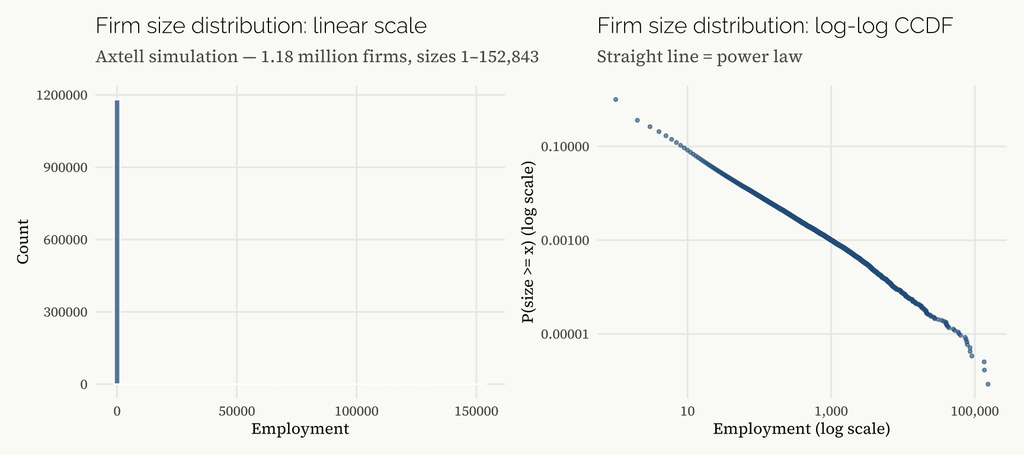

Firm size distribution on a linear scale (left) and log-log scale (right, CCDF). The dynamic range, from single-employee firms to corporations employing hundreds of thousands, defeats any visualization on a linear scale. The log-log plot reveals the power law: a straight line across many orders of magnitude.

```r
# Load Axtell simulation firm size distribution.
# Source: ../data/axtell/firm_size_distribution.csv, generated by code/parse_axtell_data.R.
# Format: size = employment (integer), count = number of firms of that size.
firm_size_dist <- read_csv("../data/axtell/firm_size_distribution.csv",
                           show_col_types = FALSE)

# Expand aggregated counts to one row per firm for downstream plotting and fitting.
# Total: ~1.18 million firms; sizes range from 1 to 152,843 employees.
firm_df <- tibble(employment = rep(firm_size_dist$size, firm_size_dist$count))

# Linear scale histogram
p_linear <- ggplot(firm_df, aes(x = employment)) +
  geom_histogram(bins = 60, fill = "#2D5F8A", alpha = 0.75, color = "white") +
  labs(
    title    = "Firm size distribution: linear scale",
    subtitle = "Axtell simulation — 1.18 million firms, sizes 1–152,843",
    x        = "Employment",
    y        = "Count"
  )

# Log-log CCDF (complementary CDF)
ccdf_df <- firm_df %>%
  arrange(employment) %>%
  mutate(
    rank = rev(seq_len(n())),
    ccdf = rank / n()
  ) %>%
  distinct(employment, .keep_all = TRUE)

p_loglog <- ggplot(ccdf_df, aes(x = employment, y = ccdf)) +
  geom_point(color = "#2D5F8A", size = 0.8, alpha = 0.6) +
  scale_x_log10(labels = scales::comma) +
  scale_y_log10(labels = scales::comma) +
  labs(
    title    = "Firm size distribution: log-log CCDF",
    subtitle = "Straight line = power law",
    x        = "Employment (log scale)",
    y        = "P(size >= x) (log scale)"
  )

p_linear + p_loglog
```

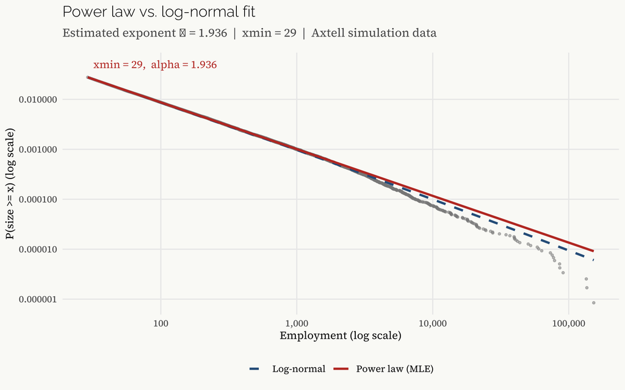

Power law fit (red line) and log-normal comparison (dashed blue) on the log-log CCDF. The power law is estimated via maximum likelihood using the package; $x_{\min}$ is selected by minimizing the Kolmogorov-Smirnov distance between the fitted distribution and the empirical data above the threshold.

```r
# Fit power law via MLE using poweRlaw
# displ: discrete power law (appropriate for integer employment counts)
m_pl  <- displ$new(firm_df$employment)
est   <- estimate_xmin(m_pl, xmax = max(firm_df$employment))
m_pl$setXmin(est)
m_pl$setPars(estimate_pars(m_pl))

alpha_hat <- m_pl$getPars()
xmin_hat  <- m_pl$getXmin()

# Fit log-normal for comparison (same xmin for fair comparison)
m_ln <- dislnorm$new(firm_df$employment)
m_ln$setXmin(xmin_hat)
m_ln$setPars(estimate_pars(m_ln))

# Compute fitted CCDFs for plotting.
# The empirical ccdf_df is the unconditional CCDF over all firms.
# Fitted distributions are conditional on x >= xmin_hat (they equal 1 at xmin_hat).
# Scale both fitted curves by the empirical CCDF at xmin_hat so they overlay correctly.
x_seq <- seq(xmin_hat, max(firm_df$employment), length.out = 200)

p_xmin <- ccdf_df %>%
  filter(employment >= xmin_hat) %>%
  slice(1) %>%
  pull(ccdf)

pl_ccdf_df <- tibble(
  x    = x_seq,
  ccdf = p_xmin * (x_seq / xmin_hat)^(-(alpha_hat - 1)),
  dist = "Power law (MLE)"
)

# Log-normal CCDF approximation via plnorm
mu_ln    <- m_ln$getPars()[1]
sigma_ln <- m_ln$getPars()[2]
ln_ccdf_df <- tibble(
  x    = x_seq,
  ccdf = p_xmin * plnorm(x_seq, meanlog = mu_ln, sdlog = sigma_ln, lower.tail = FALSE) /
         plnorm(xmin_hat, meanlog = mu_ln, sdlog = sigma_ln, lower.tail = FALSE),
  dist = "Log-normal"
)

fit_df <- bind_rows(pl_ccdf_df, ln_ccdf_df)

ggplot() +
  geom_point(
    data = filter(ccdf_df, employment >= xmin_hat),
    aes(x = employment, y = ccdf),
    color = "#888888", size = 0.8, alpha = 0.5
  ) +
  geom_line(
    data = fit_df,
    aes(x = x, y = ccdf, color = dist, linetype = dist),
    linewidth = 1.0
  ) +
  scale_x_log10(labels = scales::comma) +
  scale_y_log10(labels = scales::comma) +
  scale_color_manual(values = c("Power law (MLE)" = "#C0392B", "Log-normal" = "#2D5F8A"),
                     name = NULL) +
  scale_linetype_manual(values = c("Power law (MLE)" = "solid", "Log-normal" = "dashed"),
                        name = NULL) +
  annotate("text", x = xmin_hat * 1.1, y = 0.05,
           label = paste0("xmin = ", xmin_hat,
                          ",  alpha = ", round(alpha_hat, 3)),
           family = "Source Serif 4", size = 3.5, hjust = 0, color = "#C0392B") +
  labs(
    title    = "Power law vs. log-normal fit",
    subtitle = paste0("Estimated exponent \u03b1 = ", round(alpha_hat, 3),
                      "  |  xmin = ", xmin_hat,
                      "  |  Axtell simulation data"),
    x        = "Employment (log scale)",
    y        = "P(size >= x) (log scale)"
  )
```

## 3.2 What the Standard Models Cannot Say

The SIR system tracks three numbers: $S$, $I$, and $R$. The dynamics are fully determined by those totals. To re-express this, now in more statistical language, this is a claim about the Markov state, not merely a modeling convenience. Under the mean-field assumption, the future trajectory of the epidemic is conditionally independent of which specific individuals are susceptible or infectious, given the compartment counts. The identity of the individuals does not matter; only their number does. Individual heterogeneity averages out under random mixing, and the law of large numbers makes the aggregate dynamics deterministic functions of population totals alone. The compartment counts are the complete state of the model: once the mean-field assumption has been imposed, individual identities, histories, and contact positions have no further role in the model’s transition equations. In SIR, this assumption often served us well. Let us turn to a case where it does not.

The same logic, applied to industry dynamics, produces a model that tracks total employment or a representative firm-size parameter rather than the distribution of employment across firms. Write each firm’s employment as $\theta_i = \theta_0 + \varepsilon_i$, where $\theta_0$ is the model’s central reference parameter and $\varepsilon_i$ is firm $i$’s departure from it. The reference may be a mean when that moment exists and is scientifically appropriate, but it may instead be a median, mode, equilibrium value, or calibrated representative value. Setting $\varepsilon_i = 0$ for all firms — the representative-agent restriction — collapses the entire distribution to a point mass at $\theta_0$. The distribution of firm sizes ceases to exist as an object of the model. A world with one firm employing 200,000 workers and ten thousand firms employing fewer than ten becomes indistinguishable from one in which every firm sits at the reference value. The heterogeneity has been assumed away before the analysis begins.

The power law distribution is a property of the non-zero $\varepsilon_i$ distribution — the shape of departures from the reference value. A model that sets all $\varepsilon_i$ to zero has no mechanism through which distributional shape could arise. The restriction has eliminated the phenomenon’s carrier before estimation begins.

The deviations are not negligible perturbations around a representative value; they are the primary structure of the phenomenon. A power law has no finite mean when $\alpha \leq 2$, and even when the mean exists, it is a poor summary of the distribution’s behavior. The distribution is dominated by its tail. The largest firms in the US economy account for a substantial fraction of private-sector employment; they respond to shocks differently, shape credit conditions differently, and drive aggregate dynamics differently than a population concentrated at one reference size would. The $\varepsilon_i = 0$ restriction produces the wrong object of analysis, an object from which the distribution cannot be recovered regardless of how carefully the remaining parameters are estimated.

The firm size distribution is among the most robustly documented regularities in industrial organization — documented across a wide range of economies, periods, and sectors. A model whose language cannot express this regularity is, to that extent, describing a different economy than the one that exists.

The failure is linguistic before it is empirical. A model built on $\varepsilon_i = 0$ has no sentence in which “the distribution of firm sizes is a power law” can be written. When the language cannot contain the distribution, it has excluded the phenomenon from the territory the model covers.

**Activity — Calibration or Mechanism? (10 minutes)**

A simulation reproduces the observed firm-size tail. Which two tests would provide the strongest evidence that the result reflects a mechanism rather than calibration: refitting until the exponent matches exactly; varying parameters and initial conditions; removing or altering one behavioral rule; matching additional regularities that were not calibration targets; or adding more agents? Choose two and defend them with a partner.

## 3.3 Axtell’s Model: Logic Without Code

Robert Axtell showed that a remarkably simple agent-based model can generate a firm-size distribution consistent with the observed US regularity without targeting the empirical exponent directly (Axtell 2001). The exponent is an output of the dynamics rather than a fitted parameter.

The model is very simple. Agents allocate their effort between working alone and working as part of a team. Teams are groups of agents who have chosen to coordinate their work. Within a team, returns to scale are locally increasing: a worker who joins a team adds more than their individual marginal product, up to some point. This is not an unusual assumption about firm production — most accounts of the gains from economic organization depend on something similar.

Agents compare their current payoff within their team to alternative arrangements: a different team, or solo work. When a better option exists, agents move. Teams form when agents find mutually beneficial collaborations; teams dissolve when enough members find better alternatives elsewhere. There is no central planner, no equilibrium condition that pins down firm size, no seed distribution. The model starts from random initial conditions and runs.

The result is a power law generated by specified behavioral rules rather than fitted directly to the firm-size tail. The exponent is consistent with the empirical estimate across a range of internal parameter values. This robustness matters: it is evidence that the tail is a consequence of the interaction rules — teams forming and dissolving under local increasing returns to scale, with agents choosing from locally available alternatives — rather than an exponent inserted as a calibration target.

The model does not explain why individual firms have the sizes they have. It explains why the distribution has the shape it has. The macro regularity — the power law — is not encoded in any individual agent’s rule. No agent knows the distribution. No agent is trying to produce a power law. The distribution arises from the aggregate dynamics of agents following their individual rules, and it is not visible anywhere in those rules.

## 3.4 Emergence

For this course, a macro-level regularity is called emergent when it is not imposed as an aggregate target but arises from repeated interaction among agents and persists across relevant changes in parameters and initial conditions (Epstein and Axtell 1996; Holland 1992; Anderson 1972). Analytical intractability is neither necessary nor sufficient: some emergent patterns admit aggregate derivations, while failure to find a derivation does not prove that none exists.

The power law firm size distribution is emergent in this sense. No analysis of an individual agent’s effort allocation problem reveals the exponent. The exponent is a property of the aggregate dynamics that arise from the interaction of many individuals following local rules — insensitive to a wide range of parameter choices, structural rather than calibrated (Axtell 2001).

Axtell’s model was not fitted to the power law. The exponent emerged from the dynamics and was then compared to the data. Economists fitting equilibrium models of industry dynamics had the firm size distribution in front of them for decades — the empirical regularity was documented in the 1950s (H. A. Simon and Bonini 1958; Gibrat 1931), and the power law form was well established by the 1990s (Newman 2005) — and could not generate the exponent without external calibration. The exponent is not a property of any equilibrium. It is a property of the path: the motion of teams forming and dissolving, agents switching affiliations, distributions arising from trajectories that no equilibrium condition pins down. Equilibrium analysis specifies the destination; the distribution lives in the journey. That is why the robustness matters — the exponent is not sensitive to calibration because it is not a calibration artifact. It is structural.

This creates an explanatory asymmetry. When a model generates a known regularity without having been calibrated to it, the mechanism can be interrogated: what changes in the interaction rules would change the exponent? What perturbations to the returns-to-scale structure shift the distribution? These questions only make sense in a language that contains the generative process. A fitted model describes the distribution; a generative model explains why it has the shape it has.

The phenomenon is unreachable by any model built on $\varepsilon_i = 0$, with any parameter choices. Such a model has no dynamics in the relevant sense: it has an equilibrium at which one firm employs a fixed number of workers. There is no process of team formation and dissolution. There is no mechanism through which a distribution could be generated, because the model’s language contains no concept of a distribution of firm sizes.

Emergence, defined operationally, guides model choice. When the proposed explanation depends on heterogeneous agents repeatedly forming and dissolving teams, the model must retain that heterogeneity and process. An ABM is one natural language for writing the mechanism, but stochastic-process, kinetic, or distribution-valued models may provide others. What cannot recover the power law is the narrower class at issue here: any model that has eliminated the distribution of firm sizes from its state space.

# 4 The Possibility Space of Dynamics

```r
# Chapter 4 Setup
# Self-contained — does not depend on prior chapters.

library(tidyverse)
library(deSolve)
library(patchwork)

theme_set(
  theme_minimal(base_family = "Source Serif 4") +
    theme(
      plot.title       = element_text(family = "Raleway", face = "plain",
                                      size = 14, margin = margin(b = 8)),
      plot.subtitle    = element_text(family = "Source Serif 4", size = 11,
                                      color = "#555555", margin = margin(b = 12)),
      axis.title       = element_text(family = "Source Serif 4", size = 10),
      legend.position  = "bottom",
      panel.grid.minor = element_blank(),
      plot.background  = element_rect(fill = "#FAFAF7", color = NA)
    )
)
```

The preceding chapters used three examples — predator-prey dynamics, epidemic spread, and firm-size distributions — to make the same statistical point. A model family does not merely determine which parameters can be estimated. It determines which distinctions can enter the state space, which dependence structures can affect the outcome, and which forms of variation are treated as irrelevant by construction. This chapter names that common structure.

## 4.1 Resolution

The restriction operates differently in different models, but the consequence is always the same. The mean-field assumption removes network topology and agent heterogeneity from the model’s state space as structural restrictions imposed before estimation begins. The assumption that aggregate dynamics are determined by a single central reference parameter makes the firm size distribution inexpressible: the distribution requires heterogeneity, and the reference-point state representation asserts that this heterogeneity has no further dynamical role. The stationarity assumption makes regime change and bifurcation inexpressible — its transition law is time-invariant by construction, and it contains no bifurcation parameter through which a qualitative regime change can enter. In that sense, the language built from data generated before the bifurcation has no vocabulary for the turn. An equilibrium assumption makes path dependence inexpressible: which equilibrium the system reaches is indeterminate, and the assumption selects one by fiat.

None of these is a failure that better technique remedies. Each is a structural fact about the model’s state space and transition rules — what variables exist, what dependence structures can enter, what forms of heterogeneity are tracked. More observations do not expand the state space; more sophisticated estimation does not give the ODE a spatial dimension. The right question is not “can I fit this better?” but “does this model’s structure contain the phenomenon I need to reason about?”

Every modeling choice is a choice of resolution — temporal, spectral, expressive. The ODE, the aggregate-state closure, stationarity, equilibrium, regularization penalties, the sampling frequency of a time series — all impose structural restrictions: on the state space, on the transition law, on which agent properties enter the dynamics and which are averaged away. Each restriction makes some phenomena tractable and others unreachable. The phenomena made unreachable are not less real than the ones the model can address. They simply require distinctions — a bifurcation parameter, a spatial coordinate, a distribution of agent deviations — that the chosen structure does not carry. Here, it is useful to again distinguish structural modeling limitations from data and estimation limitations. Sometimes, we reasonably choose to ignore structure our data cannot characterize. Even here, it is often useful to embed the estimable model in a broader structural model and characterize the the relationship between the estimated model and the hypothetical class.

## 4.2 The Regularization View

The framework developed in this course interprets the ODE-ABM relationship through the geometry of regularization. This is a conceptual synthesis rather than a standard result from the ABM literature, but it rests on established mathematics — the convergence ideas of the previous section and the Bayesian-regularization equivalences discussed below. Writing it out makes visible a connection the course has been approaching from several directions simultaneously.

In an ABM, each agent $i$ carries a property vector $\theta_i$ — a birth rate, a productivity, a threshold for infection. Write $\theta_i = \theta_0 + \varepsilon_i$, where $\theta_0$ is a central reference parameter chosen by the model and $\varepsilon_i$ is the agent’s departure from it. The reference may be a mean, median, mode, equilibrium, or other scientifically defined anchor; the decomposition does not require $\sum_i \varepsilon_i=0$. The ODE is the model that sets $\varepsilon_i = 0$ for every agent — all heterogeneity collapsed to the reference value. Nothing about this restriction is forced by the biology or the economics. It is a structural choice about the distribution of agent properties, and that distribution is a point mass at $\theta_0$. An L2 penalty on $\{\varepsilon_i\}$ shrinks agents toward that reference; as the penalty strength increases, the ABM continuously approaches the ODE. From this perspective, they can be viewed as members of a common modeling family indexed by regularization strength.

The contact structure submits to the same treatment. Represent it as a weighted adjacency matrix $W$, where $W_{ij} \geq 0$ is the contact rate between agents $i$ and $j$. Every network topology is a special case: $W_{ij} = 0$ removes an edge; a heavy-tailed degree distribution produces the scale-free network from Chapter 2; the lattice concentrates all weight on immediate neighbors. Write the mean-field contact structure as $\bar{W}_{ij} = 1/(n-1)$ for $i \neq j$ and $\bar{W}_{ii} = 0$ — uniform off-diagonal contact, each agent distributing its contact weight equally across all others. Under a fixed total contact rate and no information distinguishing one potential contact from another, this uniform allocation is the least-informative contact baseline (Jaynes 1957). Every departure from $\bar{W}$ is information about contact structure beyond the mean.

Write $W = \bar{W} + \Delta W$. For off-diagonal entries, $W_{ij} \geq 0$ restricts $\Delta W_{ij} \geq -1/(n-1)$, with $W_{ii} = 0$ by construction. Together with the row-normalization constraint, these conditions define a convex feasible region. The ODE corresponds to $\Delta W = 0$. The two reparametrizations together yield the central interpretive claim of this framework: the ODE is the ABM under simultaneous regularization of agent heterogeneity toward $\theta_0$ and contact structure toward $\bar{W}$ — an identification made precise by the established Bayesian-regularization equivalences (Hoerl and Kennard 1970; Tibshirani 1996) and the convergence theorems above (Kurtz 1970, 1978). Formally, consider the objective

$$\mathcal{L}(\{\varepsilon_i\},\, \Delta
W) \;+\; \lambda_\theta \sum_i \|\varepsilon_i\|^2 \;+\; \lambda_W
\|\Delta W\|_F^2$$

As $\lambda_\theta \to \infty$ and $\lambda_W \to \infty$, the solution forces $\varepsilon_i \to 0$ and $\Delta W \to 0$, recovering the homogeneous mean-field member of the modeling family. That member yields the stated ODE when its event rules and population scaling satisfy the corresponding limit conditions. At finite $\lambda$, the solution interpolates. The regularization strengths are hyperparameters: estimable by cross-validation when individual trajectories are observed, tunable by information criteria when only aggregate data are available. The L1 and L2 penalties are convex functions of $\Delta W$ on the feasible region — this convex geometry clarifies the direction of shrinkage toward the mean-field model. The full ABM calibration problem, however, need not be convex, because the stochastic simulation map from parameters to model outputs can be highly nonlinear.

The choice between L2 and L1 on $\Delta W$ is a choice about what kind of network departure from mean-field is expected. L2 shrinks all off-diagonal edge weights uniformly toward $1/(n-1)$ under the row-normalized, no-self-contact convention — the contact structure becomes progressively closer to random mixing as $\lambda_W$ increases. L1 produces sparse $\Delta W$: most edges sit near their mean-field weight, a few carry substantial deviations. An L1 penalty on individual entries of $\Delta W$ selects sparse edge-level deviations from mean-field contact. If those deviations concentrate in the rows or columns associated with particular agents, they produce hub-like nodes with far more contacts than the mean-field allocates — precisely the Barabási-Albert structure that drove the qualitatively different epidemic dynamics in Chapter 2. Edge sparsity and hub structure are related but not identical: the former is selected by entrywise L1 regularization; the latter is a property of the distribution of row totals in the contact matrix. The parallel to LASSO remains: the penalty acts on the same convex geometry, and the sparsity-inducing property follows from the same corner-touching argument (Tibshirani 1996).

The Bayesian identity sharpens the argument further. A Laplace prior on $\Delta W_{ij}$ produces the L1 penalty at the posterior mode — exactly, not approximately, by the same algebra as for regression coefficients (Tibshirani 1996). A Gaussian prior produces L2 (Hoerl and Kennard 1970). A Gaussian prior centered at $\bar{W}$ provides one principled way to encode shrinkage toward the mean-field contact structure. The maximum-entropy argument identifies $\bar{W}$ as the least-informative contact baseline under a fixed mean contact rate; the Gaussian prior then expresses uncertainty around that baseline through an L2 penalty. The two ideas are related but should not be conflated — a flat prior over contact matrices is not generally a Gaussian centered at the mean. When the analyst has no structural knowledge of the contact network beyond its mean, L2 toward the mean-field is a principled choice. L1 is appropriate when the contact network is expected to be sparse — when most agent pairs have no meaningful contact and the consequential structure is concentrated in a few edges. The penalty encodes the prior whether or not the analyst names it as one.

The unification runs further still, but conditionally. Under squared-error linear models, small isotropic Gaussian input perturbations can induce an L2-type penalty; more generally, noise training produces a derivative-dependent Tikhonov regularizer. Distributionally robust optimization over particular Wasserstein uncertainty sets also recovers regularized estimators as special cases (Duchi and Namkoong 2021). Bayesian prior, regularization penalty, and perturbation budget are connected constructions, not interchangeable descriptions in every model. The literature on mean-field games establishes limiting behavior at infinite scale by different means: under appropriate assumptions as $n \to \infty$ with individual effects shrinking proportionally, a discrete agent system converges to a continuum PDE, studied with the tools of optimal control (Lasry and Lions 2007; Huang et al. 2006). Reading this as the $\lambda \to \infty$ endpoint of a regularization path is this framework’s interpretation, not the literature’s own framing.

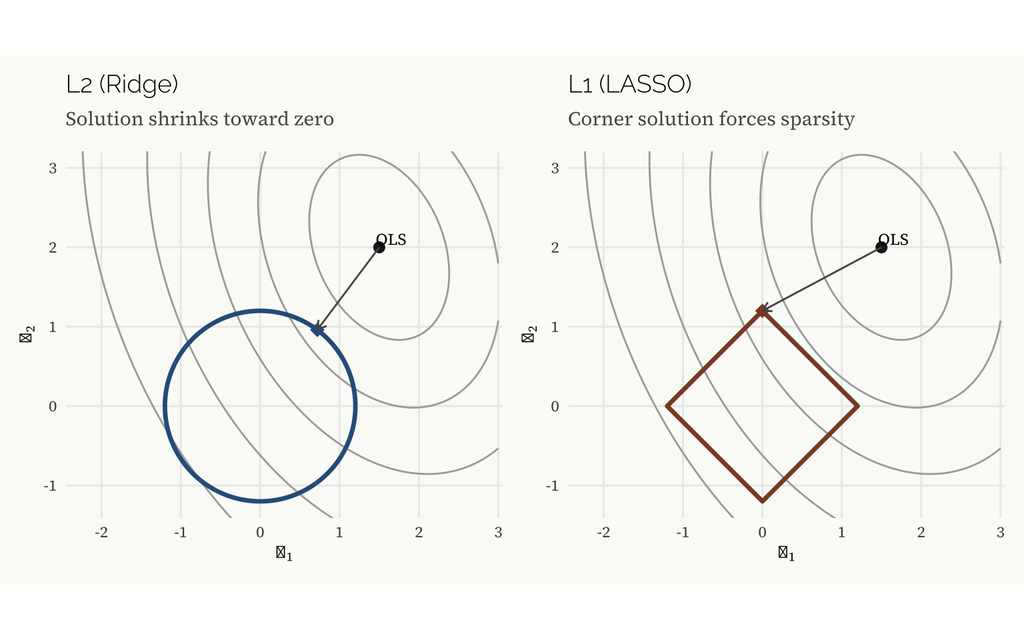

Geometry of regularization. Coefficient contours (ellipses) intersect the constraint region at the regularized solution. L2 (ridge) penalty produces a circular constraint region; the solution is generally interior with all coefficients shrunk toward zero. L1 (LASSO) penalty produces a diamond constraint region; the solution tends to land on a corner, producing sparse solutions with some coefficients exactly zero.

```r
# Visualize the geometry of L1 vs L2 regularization
# The plot shows coefficient contours and constraint regions

# RSS contours centered at OLS estimate (beta1=1.5, beta2=2.0 for illustration)
beta1_ols <- 1.5
beta2_ols <- 2.0

# Grid for contour computation
b1 <- seq(-2.5, 3, length.out = 300)
b2 <- seq(-1.5, 3.5, length.out = 300)
grid_reg <- expand.grid(b1 = b1, b2 = b2) %>% as_tibble()

# RSS surface (simplified: circular contours scaled from OLS)
# Using anisotropic ellipses to reflect correlated predictors
grid_reg <- grid_reg %>%
  mutate(
    rss = 0.7 * (b1 - beta1_ols)^2 +
          0.4 * (b2 - beta2_ols)^2 +
          0.3 * (b1 - beta1_ols) * (b2 - beta2_ols)
  )

# L2 constraint region: circle of radius r
r_l2 <- 1.2
constraint_l2 <- tibble(
  angle = seq(0, 2*pi, length.out = 300),
  b1    = r_l2 * cos(angle),
  b2    = r_l2 * sin(angle)
)

# L1 constraint region: diamond |b1| + |b2| <= r
r_l1 <- 1.2
constraint_l1 <- tibble(
  b1 = c(r_l1, 0, -r_l1, 0, r_l1),
  b2 = c(0, r_l1, 0, -r_l1, 0)
)

# Ridge solution: project OLS onto L2 ball (simple approximation)
scale_factor_l2 <- r_l2 / sqrt(beta1_ols^2 + beta2_ols^2)
ridge_soln <- tibble(b1 = beta1_ols * scale_factor_l2,
                     b2 = beta2_ols * scale_factor_l2,
                     label = "Ridge solution")

# LASSO solution: tends toward axis (corner of diamond)
# Approximate: project onto nearest corner
if (abs(beta1_ols) > abs(beta2_ols)) {
  lasso_soln <- tibble(b1 = r_l1, b2 = 0, label = "LASSO solution")
} else {
  lasso_soln <- tibble(b1 = 0, b2 = r_l1, label = "LASSO solution")
}

p_l2 <- ggplot() +
  geom_contour(data = grid_reg, aes(x = b1, y = b2, z = rss),
               color = "#AAAAAA", breaks = c(0.5, 1.5, 3.0, 5.5, 9.0)) +
  geom_path(data = constraint_l2, aes(x = b1, y = b2),
            color = "#2D5F8A", linewidth = 1.2) +
  geom_point(aes(x = beta1_ols, y = beta2_ols), color = "#1C1C1E", size = 2.5) +
  geom_point(data = ridge_soln, aes(x = b1, y = b2),
             color = "#2D5F8A", size = 3.5, shape = 18) +
  geom_segment(aes(x = beta1_ols, y = beta2_ols,
                   xend = ridge_soln$b1, yend = ridge_soln$b2),
               arrow = arrow(length = unit(0.2, "cm")), color = "#555555") +
  annotate("text", x = beta1_ols + 0.15, y = beta2_ols + 0.1,
           label = "OLS", family = "Source Serif 4", size = 3.2) +
  labs(title = "L2 (Ridge)",
       subtitle = "Solution shrinks toward zero",
       x = expression(beta[1]), y = expression(beta[2])) +
  coord_equal(xlim = c(-2.2, 2.8), ylim = c(-1.2, 3.0))

p_l1 <- ggplot() +
  geom_contour(data = grid_reg, aes(x = b1, y = b2, z = rss),
               color = "#AAAAAA", breaks = c(0.5, 1.5, 3.0, 5.5, 9.0)) +
  geom_polygon(data = constraint_l1, aes(x = b1, y = b2),
               fill = NA, color = "#8A4A2D", linewidth = 1.2) +
  geom_point(aes(x = beta1_ols, y = beta2_ols), color = "#1C1C1E", size = 2.5) +
  geom_point(data = lasso_soln, aes(x = b1, y = b2),
             color = "#8A4A2D", size = 3.5, shape = 18) +
  geom_segment(aes(x = beta1_ols, y = beta2_ols,
                   xend = lasso_soln$b1, yend = lasso_soln$b2),
               arrow = arrow(length = unit(0.2, "cm")), color = "#555555") +
  annotate("text", x = beta1_ols + 0.15, y = beta2_ols + 0.1,
           label = "OLS", family = "Source Serif 4", size = 3.2) +
  labs(title = "L1 (LASSO)",
       subtitle = "Corner solution forces sparsity",
       x = expression(beta[1]), y = expression(beta[2])) +
  coord_equal(xlim = c(-2.2, 2.8), ylim = c(-1.2, 3.0))

p_l2 + p_l1
```

Every model involves two levels of restriction, and the reparametrization makes both legible. The first is the model family — the structural commitment that determines what phenomena are in scope. The mean-field ODE is a family: it fixes $\varepsilon_i = 0$ and $\Delta W = 0$ before any data are seen, admitting mass-action interactions in continuous time and excluding network structure, spatial heterogeneity, and discrete individual effects entirely. The aggregate-state model of industry dynamics is a family: it admits dynamics driven by aggregate employment and excludes the distributional heterogeneity that generates the power law tail. The stationary time series is a family: it admits processes whose spectral structure is constant across time and excludes regime transitions. These are not parameter choices. They are structural commitments that determine what the model can say, and no quantity of data revises them — they are the grammar within which the data are interpreted.

The second level is the prior on that family — the regularization, calibrated to what the data at a particular observation frequency can support. The choice of penalty is a choice of prior, and the prior encodes beliefs about how far the true system sits from the family’s anchor point: how heterogeneous the agents are, how far the contact network departs from the least-informative mean-field baseline, how sparse the consequential deviations are. The ABM critic who objects to parameter proliferation is demanding stronger regularization within a richer family — sometimes legitimate when the data cannot distinguish the parameters, illegitimate when the phenomenon requires the richer family to exist at all. Both levels interact with observation frequency: the family must be appropriate at the resolution of measurement, and the prior on the family must be calibrated to what that resolution can support. When the phenomenon is the mean-field limit of large-population randomly-mixed dynamics, the ODE is correct and additional expressiveness contributes nothing. When the phenomenon is the shape of the firm size distribution, or the topology-dependence of an epidemic, the restricted family does not fit poorly — it excludes the phenomenon by design, before estimation begins.

## 4.3 Temporal Resolution and Near-Decomposability

All data are time-indexed. The firm size distribution has a year attached to it. The epidemic curve begins at a date. The regression coefficients are estimated from observations generated over a period. Sometimes the time label is displayed; sometimes it is known and suppressed; sometimes it is genuinely unknown. But the time structure is always present in the data-generating process, and every choice — of model family, of prior on that family — is a choice about how to handle it. The model family determines which temporal structures are accessible to inference. The prior on the family determines what is estimable at the available observation frequency. Making these choices explicit, rather than allowing them to hide in the model’s functional form, is the discipline the framework demands.

Herbert Simon observed that complex adaptive systems tend to be nearly decomposable: subsystems interact tightly at fast time scales and loosely at slow ones (H. A. Simon 1962). A firm coordinates its internal operations at time scales too fast for prices to clear across firms. The economy coordinates across firms at time scales over which transaction costs can be overcome. Each level of organization has its characteristic frequency. The levels are not isolated from each other, but they are not fully coupled either — the fast dynamics within each level are approximately independent of the slow dynamics between levels.

Data recorded at a fixed temporal resolution have already passed through an observation filter: faster dynamics may be averaged, aliased, or absorbed into aggregate coefficients (Nyquist 1928; Shannon 1949). A model fitted only to quarterly aggregates cannot identify arbitrary within-quarter ordering from those observations alone, although faster processes may still affect the aggregates. Finer collection can change what is identifiable; given the existing design, the fitted model inherits its temporal resolution. The resolution choice therefore constrains which phenomena are accessible to inference.

Stationarity is the temporal counterpart of the mean-field assumption — not analogously but structurally, because both are structural model-family choices. The mean-field family averages over spatial heterogeneity within each time step, asserting that contact structure is uniform across all pairs of agents. The stationary family averages over temporal heterogeneity across the observation window, asserting that the data-generating process at time $t$ is drawn from the same distribution as at time $t - k$ for all $k$. One suppresses spatial structure; the other suppresses temporal structure. Both determine what the model can express, and both interact with observation frequency in the same way: the family is appropriate when the dimension being averaged over is genuinely negligible at the relevant resolution, and misspecified when it is not.

Sampling frequency determines which structural model-family choices are testable from the available data. For regularly sampled time series, periodic components with periods shorter than twice the sampling interval cannot be recovered without aliasing — weekly data cannot reliably identify sub-biweekly oscillatory structure, and more generally the sampling frequency limits which temporal features of the data-generating process can be recovered from the observed series. A stationary model fitted to weekly observations constrains the law represented at that observational scale; it does not establish that faster processes are absent. Stationarity at that resolution is distinct from stationarity at finer resolutions, and the answers can differ in a multiscale system. A fixed-regime stationary model without a changing control parameter cannot represent a bifurcation driven by such a parameter; this is a limitation of that specification, not of every stationary process.

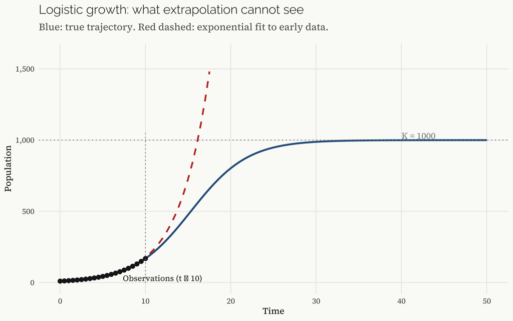

The extrapolation trap. A logistic growth process observed only in its early exponential phase (solid black points, t $\leq$ 10) yields an exponential fit (dashed red) that projects unbounded growth. The true trajectory (solid blue) reaches a carrying capacity that is invisible from the early data. The turn is not outside the confidence interval of the fit; it is outside the language of the model fitted to the early data.

```r
set.seed(2025)  # seed for reproducibility

K  <- 1000   # carrying capacity
r  <- 0.3    # intrinsic growth rate
N0 <- 10     # initial population

t_full <- seq(0, 50, by = 0.5)
N_true <- K / (1 + ((K - N0) / N0) * exp(-r * t_full))

logistic_df <- tibble(t = t_full, N = N_true)

# Observed data: only the exponential phase (t <= 10)
obs_df <- filter(logistic_df, t <= 10)

# Fit a linear model to log(N) ~ t on the observed data
# This corresponds to fitting an exponential model
lm_fit  <- lm(log(N) ~ t, data = obs_df)
r_hat   <- coef(lm_fit)["t"]
N0_hat  <- exp(coef(lm_fit)["(Intercept)"])

# Extrapolate using the fitted exponential
pred_df <- tibble(t = seq(0, 50, by = 0.5)) %>%
  mutate(N_pred = N0_hat * exp(r_hat * t))

ggplot() +
  # True logistic trajectory
  geom_line(data = logistic_df, aes(x = t, y = N),
            color = "#2D5F8A", linewidth = 1.0) +
  # Exponential extrapolation
  geom_line(data = pred_df, aes(x = t, y = N_pred),
            color = "#C0392B", linewidth = 0.9, linetype = "dashed") +
  # Observed data points
  geom_point(data = obs_df, aes(x = t, y = N),
             color = "#1C1C1E", size = 2.0) +
  # Carrying capacity reference
  geom_hline(yintercept = K, color = "#888888", linetype = "dotted") +
  annotate("text", x = 42, y = K + 30, label = paste0("K = ", K),
           family = "Source Serif 4", size = 3.5, color = "#888888") +
  annotate("text", x = 12, y = 30,
           label = "Observations (t \u2264 10)", size = 3.2,
           family = "Source Serif 4", color = "#1C1C1E") +
  annotate("segment", x = 10, xend = 10, y = 0, yend = K + 50,
           linetype = "dotted", color = "#888888") +
  scale_y_continuous(labels = scales::comma, limits = c(0, 1600)) +
  labs(
    title    = "Logistic growth: what extrapolation cannot see",
    subtitle = "Blue: true trajectory. Red dashed: exponential fit to early data.",
    x        = "Time",
    y        = "Population"
  )
```

The logistic example is the stripped-down version of a general problem. Any system capable of bifurcation will defeat stationarity-based extrapolation at the bifurcation point. The early-phase data are generated by one dynamical regime; the post-bifurcation data are generated by another. A model fitted to the early-phase data has learned the parameters of a regime that no longer exists. This is not a statistical point about forecast intervals being too narrow. It is a structural point about the limits of inductive inference from time series in nonlinear systems. The carrying capacity is not a parameter that the exponential model can estimate with more data. It is a parameter that the exponential model does not have.

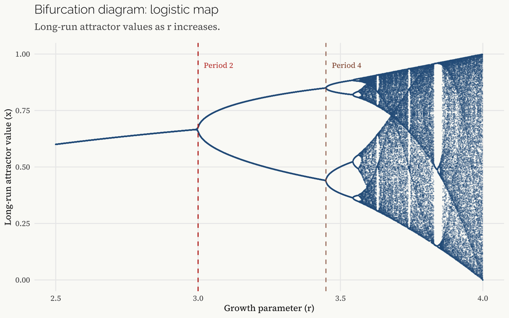

Bifurcation diagram of the logistic map $x_{t+1} = r x_t(1 - x_t)$. For $r < 3$, the system converges to a single fixed point. At $r = 3$, a period-doubling bifurcation occurs. By $r \approx 3.57$, the system enters chaos. A time series model fitted to data from $r = 2.8$ has no representation for the behavior at $r = 3.5$: the bifurcation is exterior to the language of the stationary model.

```r
set.seed(2025)  # reproducibility

# Logistic map attractor: iterate the map and collect long-run values
map_attractor <- function(r_val, n_burn = 500, n_keep = 200) {
  # n_burn: transient steps discarded before collecting
  # n_keep: steps collected for plotting
  x <- 0.5  # initial condition (interior of [0,1])
  for (i in seq_len(n_burn)) x <- r_val * x * (1 - x)
  xs <- numeric(n_keep)
  for (i in seq_len(n_keep)) {
    x    <- r_val * x * (1 - x)
    xs[i] <- x
  }
  tibble(r = r_val, x = xs)
}

# Sweep over r values
bif_df <- map_dfr(
  seq(2.5, 4.0, length.out = 1200),
  map_attractor,
  n_burn = 500,
  n_keep = 150
)

ggplot(bif_df, aes(x = r, y = x)) +
  geom_point(size = 0.05, alpha = 0.3, color = "#2D5F8A") +
  geom_vline(xintercept = 3.0, linetype = "dashed", color = "#C0392B", linewidth = 0.6) +
  geom_vline(xintercept = 3.449, linetype = "dashed", color = "#8A4A2D",
             linewidth = 0.6, alpha = 0.7) +
  annotate("text", x = 3.02, y = 0.95, label = "Period 2",
           family = "Source Serif 4", size = 3.0, color = "#C0392B", hjust = 0) +
  annotate("text", x = 3.47, y = 0.95, label = "Period 4",
           family = "Source Serif 4", size = 3.0, color = "#8A4A2D", hjust = 0) +
  labs(
    title    = "Bifurcation diagram: logistic map",
    subtitle = "Long-run attractor values as r increases.",
    x        = "Growth parameter (r)",
    y        = "Long-run attractor value (x)"
  )
```

A time series model calibrated only on data from the stable fixed-point regime ($r < 3$), with $r$ fixed or omitted, has learned the dynamics of that regime. At $r = 3$, the underlying system bifurcates to a period-two cycle. Stationarity alone does not forbid cycles, nor does a time-invariant transition law forbid a control parameter. The limitation arises because this fitted model contains no varying $r$ through which the regime change can enter. The turn is therefore a transition outside the particular model class that was fitted, not outside stationary modeling in general.

## 4.4 The Epistemology of Turning Points

Any trend extrapolated far enough produces an absurdity. A bond that compounds at five percent for long enough exceeds global GDP. A population growing at one percent doubles in seventy years and doubles again, until someone notices that the land does not. These projections are accurate outputs of models whose language contains no word for the ceiling. The problem is not extreme extrapolation. It is that any model built from data within a single phase of a cyclical system is, by construction, a model of that phase — and a phase, extrapolated, is infinite.

The observation that human affairs cycle rather than trend is old enough that its antiquity should give pause. Polybius, writing after Carthage, described anacyclosis: the sequence from monarchy through tyranny, from aristocracy through oligarchy, from democracy through mob rule and back to the need for monarchy (Polybius 2010). The form is not random deterioration but a structured progression, each stage generating the conditions that produce the next. The Platonic version is more pessimistic: the sequence runs in one direction, each form a degradation of the last. What both share, and what matters here, is the structure of the claim. Stability is not neutral. It is generative — of the conditions that will end it.

Ibn Khaldun, writing in the fourteenth century, gave this intuition an unusually systematic early treatment (Ibn Khaldun 1377). Dynastic power rises on the strength of *asabiyyah* — group solidarity, the capacity for collective action that desert tribes possess in greater abundance than the sedentary populations they displace. Success dilutes it. Urban comfort, internal competition, the purchase of mercenary armies in place of kin-based ones: the mechanisms by which a dynasty’s own dominance dissolves its original advantage are detailed, not vague. The cycle has a period: Ibn Khaldun estimated roughly four generations, approximately a century. The collapse of a dynasty is consistent with the account, because collapse is among the outcomes it predicts; discriminating evidence would need to test the proposed mechanism and timing.

Nikolai Kondratiev, writing in the 1920s, found a similar structure in industrialized economies. Long waves of approximately fifty years — expansion followed by contraction — seemed to characterize the historical series of prices, output, and interest rates since the beginning of industrial capitalism. Kondratiev did not explain the waves; he identified them (Kondratiev 1925). Schumpeter supplied the mechanism (Schumpeter 1939). Each wave is driven by a cluster of general-purpose technologies — the steam engine, the railways, electrification, the internal combustion engine — that open new productive frontiers, stimulate investment and employment through the expansion phase, and eventually saturate. The carrying capacity of any particular technological wave is finite. The expansion ends not because demand runs out but because the opportunities the technology created have been realized. The language of the expansion phase, fitted to expansion data, has no parameter for saturation.

Hyman Minsky’s version may be the sharpest. Stability, he argued, breeds instability — not as metaphor but as mechanism (Minsky 1992). A period of financial calm licenses leveraged risk-taking: lenders relax standards, borrowers extend, asset prices rise to reflect the expectation that they will continue to rise. The longer the calm persists, the more the system’s structure shifts toward fragility, because the calm is evidence — compelling, well-fitted evidence — that leverage is safe. A lender operating from a model calibrated on the calm period is not simply being irrational. The model is a good fit to the data it was fitted on. It simply has no representation for the regime change that the calm’s own dynamics are producing. The Minsky moment, when it comes, is not an outlier the model underweighted. It is a structural change into a regime the model could not express.

Reinhart and Rogoff catalogued eight centuries of financial crises and documented a recurrent pattern: confident claims that old constraints no longer applied, that the current cycle was different, or that leverage was sustainable (Reinhart and Rogoff 2009). One interpretation is not simple irrationality but model dependence: models fitted to tranquil pre-crisis data may represent that regime well while omitting mechanisms that make the regime unstable. The crisis can then arrive as a structural change outside the fitted model’s vocabulary.

[figure not shown]

```r
set.seed(2025)  # reproducibility

# Stylized long-wave cycle: sustained oscillation around a stable mean.
# Period of 50 units, echoing Kondratiev's empirical estimate.
t_full    <- seq(0, 130, by = 0.5)
baseline  <- 100
amplitude <- 35
period    <- 50
signal    <- baseline + amplitude * sin(2 * pi * t_full / period)

# Add a small amount of noise to represent real data
noise     <- rnorm(length(t_full), 0, 2)
cycle_df  <- tibble(t = t_full, true = signal, observed = signal + noise)

# Window A: expansion phase — the upswing (t ∈ [5, 20])
win_a <- filter(cycle_df, t >= 5, t <= 20)
fit_a <- lm(observed ~ t, data = win_a)

# Window B: contraction phase — the downswing (t ∈ [32, 47])
win_b <- filter(cycle_df, t >= 32, t <= 47)
fit_b <- lm(observed ~ t, data = win_b)

# Extrapolate each fit forward to t = 75
extrap_t <- seq(5, 75, by = 0.5)
extrap_df <- bind_rows(
  tibble(t = extrap_t, fit = predict(fit_a, tibble(t = extrap_t)), window = "Expansion fit"),
  tibble(t = extrap_t, fit = predict(fit_b, tibble(t = extrap_t)), window = "Contraction fit")
)

# Shade the observation windows
shade_a <- tibble(xmin = 5,  xmax = 20, ymin = 40, ymax = 165)
shade_b <- tibble(xmin = 32, xmax = 47, ymin = 40, ymax = 165)

ggplot() +
  # Shaded observation windows
  geom_rect(data = shade_a, aes(xmin = xmin, xmax = xmax, ymin = ymin, ymax = ymax),
            fill = "#2D5F8A", alpha = 0.08) +
  geom_rect(data = shade_b, aes(xmin = xmin, xmax = xmax, ymin = ymin, ymax = ymax),
            fill = "#C0392B", alpha = 0.08) +
  # True cycle (shown after observation period as dotted)
  geom_line(data = filter(cycle_df, t <= 75),
            aes(x = t, y = true),
            color = "#555555", linewidth = 0.8, linetype = "dotted") +
  # Observed data points in each window
  geom_point(data = win_a, aes(x = t, y = observed),
             color = "#2D5F8A", size = 1.5, alpha = 0.8) +
  geom_point(data = win_b, aes(x = t, y = observed),
             color = "#C0392B", size = 1.5, alpha = 0.8) +
  # Extrapolations
  geom_line(data = extrap_df,
            aes(x = t, y = fit, color = window, linetype = window),
            linewidth = 0.85) +
  scale_color_manual(
    values = c("Expansion fit" = "#2D5F8A", "Contraction fit" = "#C0392B")
  ) +
  scale_linetype_manual(
    values = c("Expansion fit" = "solid", "Contraction fit" = "solid")
  ) +
  annotate("text", x = 12.5, y = 155, label = "Window A\n(expansion)",
           family = "Source Serif 4", size = 3.0, color = "#2D5F8A") +
  annotate("text", x = 39.5, y = 155, label = "Window B\n(contraction)",
           family = "Source Serif 4", size = 3.0, color = "#C0392B") +
  coord_cartesian(ylim = c(45, 165)) +
  labs(
    title    = "Two windows, two extrapolations",
    subtitle = "Dotted: true cycle. Shaded: windows. Solid: linear extrapolations.",
    x        = "Time",
    y        = "Index",
    color    = NULL,
    linetype = NULL
  ) +
  theme(legend.position = "bottom")
```

This is the genealogy of a fixed-regime extrapolation problem. Stationarity is not merely an assumption about noise; it constrains which distributional features remain invariant over time. A stationary process may contain cycles, but a model fitted within one regime and lacking a variable for the transition cannot anticipate a turn driven by omitted regime structure. Its failure belongs to that specification, not to stationary modeling as a whole.

The Kondratiev observation, the Minsky mechanism, the Ibn Khaldun genealogy of dynasties — these are all claims that the most important events in the system’s history are phase transitions, and that models fitted within a phase are, by construction, blind to them. This is not a counsel of despair about time series modeling. It is a demand for precision about what time series models can and cannot say, and therefore about which questions they can and cannot answer. A model may fit the expansion phase. The question of whether the expansion will continue is a question about the regime structure — about where in the cycle the system currently sits, and what conditions govern the transition — and it is exterior to the language of any model that takes the expansion phase as its universe.

## 4.5 A Genealogy of the Catastrophist Error

The cyclical thinkers described in the previous section — Ibn Khaldun, Kondratiev, Minsky — share one structural commitment: the system recovers. The trough precedes a new expansion; the collapsed dynasty is replaced by a vigorous successor; the Minsky moment clears the leverage and the cycle continues. There is a parallel tradition, possibly older and quantitatively more elaborated, that draws the opposite conclusion from the same observation of decline: the trajectory does not reverse. It continues to zero.

The catastrophist template is older than any of its modern instances. The Babylonian *Atrahasis* epic (c. 1700 BCE) states the precipitating condition without ceremony: “the land was bellowing like a bull; the god grew restless at their clamour” — and flood follows (Dalley 1989). The opening chapters of Genesis present the earth “filled with violence” — a condition the tradition consistently glossed as the consequence of unchecked human multiplication — met by the same correction. The structural claim is the same as Malthus’s: excess growth ends in catastrophic reduction, and the question of what might prevent the trajectory from reaching zero does not arise, because the answer is stipulated. Nothing within the world stops it. The correction is external, total, and not subject to model revision.

Plato returned to the structure in the *Timaeus*, where periodic catastrophes — floods, conflagrations — periodically reset civilization to its pastoral minimum (Plato 2016). The upland shepherds survive; the coastal cities do not. Civilization is a deviation from a simpler baseline, and the baseline reasserts itself by external mechanism. In the *Laws*, Plato specifies 5,040 as the optimal size for a well-governed city and proposes mechanisms for controlling population that exceed this number (Plato 1988). The arithmetic matters less than the structure: population is a variable to be fixed from outside, because the internal dynamics of growth have no natural corrective within the model’s language.

Aristotle posed the right question and gave the predictable answer. Criticizing Plato’s failure to specify what happens when population grows beyond the ideal in the *Politics*, he concluded that unchecked numbers produce poverty (Aristotle 1998). The Malthusian inference in miniature: growth without limit produces scarcity, and scarcity is the attractor. The question was correct. The structural deficit was not: no mechanism for voluntary fertility decline, no representation for the productivity growth that decouples output from population, no attractor other than the one at the end of the extrapolated line.

Tertullian, writing around 210 CE, is the sharpest ancient instance (Tertullian 1950). In *De Anima* he observes that the earth has become insufficient: our numbers are burdensome to the world, which can hardly supply our needs; pestilence, famine, and war have come to be regarded as remedies, since they prune the luxuriant growth of the human race. The language is indistinguishable from the 1798 *Essay*. The mechanism is indistinguishable. The structural error is indistinguishable. Tertullian predates Malthus by sixteen centuries and commits the same mistake with the same vocabulary: no word for the demographic transition, no word for the agricultural revolution, no attractor other than catastrophic correction imposed from outside the model’s expressive range.

Thomas Malthus, in 1798, argued that population tends to grow geometrically while food production grows arithmetically, creating pressures checked by famine, disease, and war (Malthus 1798). As a general long-run forecast, that simple formulation did not anticipate major demographic and agricultural transitions. The demographic transition and productivity revolutions in agriculture are not merely different numerical values for its growth parameters; they require mechanisms absent from the simple formulation. Its catastrophic projection depends on holding such outside mechanisms absent, while historically several of them mattered.

William Stanley Jevons raised the structure one level in 1865. Britain’s coal was finite, consumption was growing, therefore industrial civilization would eventually exhaust its substrate (Jevons 1865). Jevons added a subtlety Malthus lacked: he observed that more efficient steam engines had increased coal consumption rather than reduced it, because lower cost expanded demand faster than efficiency contracted it. His model still had no mechanism for the substitution of one energy substrate for another, or for the migration of industrial processes away from coal entirely. The resource it tracked was coal; the thing it failed to see was that the binding constraint was energy, whose definition was not fixed.

The most technically elaborate version of the argument appeared in 1972. Jay Forrester’s system dynamics framework, applied by Meadows and colleagues in *The Limits to Growth* (Meadows et al. 1972), coupled population, industrial output, food production, resource depletion, and pollution in a system of differential and stock-flow equations. World3 explored several technology and policy scenarios, but important responses — including price-mediated substitution and decentralized adaptation by heterogeneous agents — were absent or represented exogenously and at aggregate resolution. A model with endogenous innovation or heterogeneous adaptive agents would therefore describe a broader mechanism space than the baseline World3 scenarios.

The Simon-Ehrlich wager of 1980 is of particular statistical interest. Paul Ehrlich had written in 1968 that “the battle to feed all of humanity is over” and that in the 1970s “hundreds of millions of people will starve to death in spite of any crash programs embarked upon now” (Ehrlich 1968). Wagering on resource scarcity, he bet that the real prices of five commodity metals would rise over the following decade. Julian Simon took the other side (J. L. Simon 1981). By 1990, all five prices had fallen. There was overconfidence on both sides, and shifting the observation window could have changed the result. The episode nevertheless illustrates mechanisms a fixed-scarcity extrapolation can omit: price signals may induce exploration, efficiency improvements, and substitution across materials and processes. One wager cannot identify which mechanism caused the price movement, but it makes the omitted-mechanism question unavoidable.

The pattern has repeated. Hubbert’s logistic depletion curve (Hubbert 1956), correct for US lower-48 conventional oil production, was generalized to a global supply model and used to predict catastrophic oil shortage, repeatedly, from the 1970s through the 2000s. Each prediction failed through the same structural deficit: the models had no representation for unconventional reserves, for the technological frontier in extraction, for demand-side adaptation under rising prices. The resource proved more heterogeneous than the model allowed, and the agents more adaptive.

What unifies this genealogy is a specific error: the over-generalization of locality. Each model in the sequence observes a local trajectory — a resource depleting at the current extraction rate, a population growing under current technology — and generalizes from the local slope to a global claim about the system’s fate. The inference is valid only if the local behavior fully characterizes the attractor structure: if the system has no other basin, no adaptive mechanisms, no possibility outside the trajectory currently observed. The catastrophist model makes this assumption by construction. It is a model with one attractor, in a language that cannot represent the mechanisms that would produce another.

This is not pessimism. It is a failure of cartography. The question the model cannot ask is: what qualitatively distinct futures are accessible from the current state, under what structural conditions does each obtain, and what observables or interventions govern which the system enters? The cyclical tradition and the catastrophist tradition cannot be distinguished by their trajectories. A declining resource is consistent with both a periodic trough and an approach to genuine collapse. Local extrapolation is silent on which regime the system occupies. That question is structural — it requires knowledge of the attractors, the mechanisms, and the boundaries between them — and it is exterior to the language of any model that takes the current phase as its universe.

## 4.6 The Possibility Space

The agent-based model does not generally produce better point forecasts. Nor should it be considered a superior extrapolation engine. A model that represents the full heterogeneity of a firm population does not thereby know where the economy will be in ten years with more precision than a model tracking a single representative firm-size parameter does. Forecasting is not the point.

What the ABM offers is a map of the possibility space — the range of qualitatively distinct behaviors the system is capable of producing, the conditions under which each is realized, and the locations of the boundaries between them. These boundaries are not forecast errors. They are structural features of the system’s dynamics. A map that shows them is a different kind of knowledge than a point forecast, and in many circumstances it is more useful.

Consider the contrast. A policy advisor working from a single trajectory — “the economy will grow at 2.3% next year, inflation will be 3.1%” — is navigating with a point. The point may be calibrated well or poorly; either way, it is a point. A policy advisor working from a possibility space map knows which dynamical regimes are accessible from the current state, what conditions would trigger a transition between them, and which interventions have leverage at the critical points. The map does not eliminate uncertainty. It characterizes it structurally, rather than reporting a number that suppresses the structure by design.

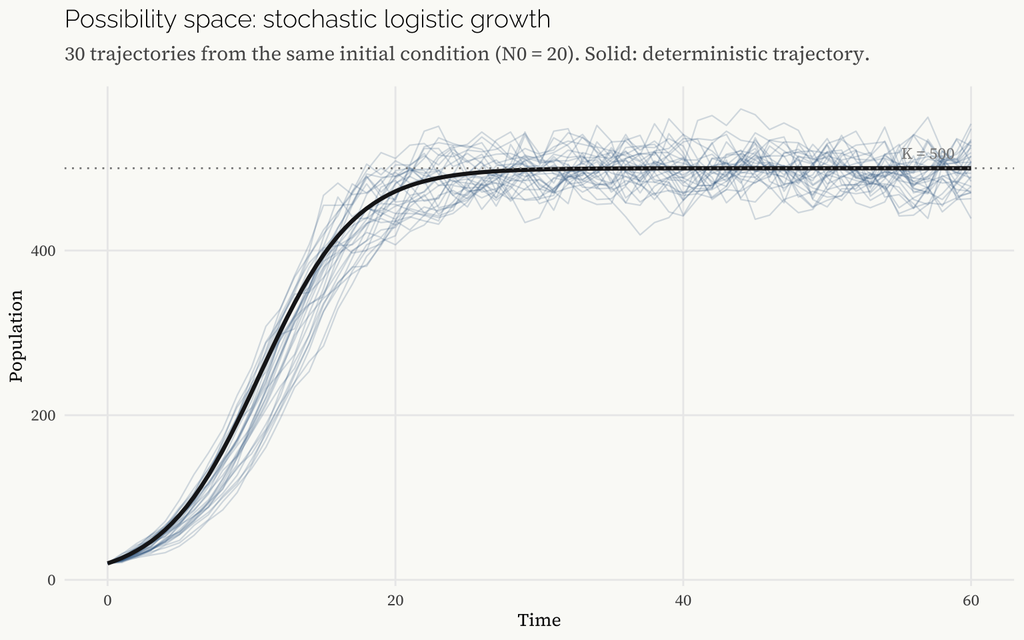

```r
set.seed(2025)  # reproducibility

# Stochastic logistic growth: same starting point, different trajectories
# Stochasticity comes from demographic noise (discreteness of individuals)
r_growth <- 0.3
K_cap    <- 500
N_start  <- 20
T_traj   <- 60
n_traj   <- 30

run_stochastic_logistic <- function(seed, N0, r, K, T) {
  set.seed(seed)
  N <- N0
  traj <- numeric(T + 1)
  traj[1] <- N

  for (tt in 2:(T + 1)) {
    # Demographic stochasticity: births ~ Poisson(r*N), deaths ~ Poisson(r*N^2/K)
    # E[births - deaths] = r*N - r*N^2/K = r*N*(1 - N/K) = logistic net growth
    # This parameterization ensures the deterministic trajectory is the mean of
    # the stochastic cloud, so the black reference line sits centered in the cloud.
    births <- rpois(1, r * N)
    deaths <- rpois(1, r * N^2 / K)
    N      <- max(0, N + births - deaths)
    traj[tt] <- N
  }

  tibble(t = 0:T, N = traj, seed = seed)
}

trajectories_df <- map_dfr(1:n_traj, run_stochastic_logistic,
                            N0 = N_start, r = r_growth, K = K_cap, T = T_traj)

# Deterministic solution for reference
t_det <- seq(0, T_traj, by = 0.5)
N_det <- K_cap / (1 + ((K_cap - N_start) / N_start) * exp(-r_growth * t_det))
det_df <- tibble(t = t_det, N = N_det)

ggplot() +
  geom_line(
    data = trajectories_df,
    aes(x = t, y = N, group = seed),
    alpha = 0.2, linewidth = 0.4, color = "#2D5F8A"
  ) +
  geom_line(
    data = det_df,
    aes(x = t, y = N),
    color = "#1C1C1E", linewidth = 1.1
  ) +
  geom_hline(yintercept = K_cap, linetype = "dotted", color = "#888888") +
  annotate("text", x = T_traj - 3, y = K_cap + 18,
           label = paste0("K = ", K_cap), family = "Source Serif 4",
           size = 3.2, color = "#888888") +
  labs(
    title    = "Possibility space: stochastic logistic growth",
    subtitle = paste0(n_traj, " trajectories from the same initial condition (N0 = ", N_start, "). ",
                      "Solid: deterministic trajectory."),
    x        = "Time",
    y        = "Population"
  )
```

This is what honest cartography looks like. Not “the population will be $K$ at time $T$” but “these are the trajectories accessible from this starting point, these are the conditions that push toward the upper envelope, and extinction is accessible when the population falls below a certain threshold from which recovery becomes unlikely.” The map and the point forecast are not competing. They are answers to different questions — and the question the map answers is often the more useful one.

## 4.7 The Statistician’s Checklist

**Activity — Choose the Minimum Sufficient Model (15 minutes)**

Choose one task: forecast total influenza hospitalizations; allocate vaccines when supply is limited; explain the firm-size distribution; or assess whether stable growth could cross into another regime. Name the least expressive model that can answer the question, the data needed to justify that resolution, and one conclusion the chosen model cannot support. Begin the defense with: *This question requires…*

The statistician’s instinct toward honest uncertainty quantification is correct. Confidence intervals, posterior distributions, prediction intervals, cross-validation — these are all ways of refusing to report false precision. They are formal structures for saying “I do not know exactly, and here is what I do know about how much I do not know.” This course has argued that the same instinct should extend from parameter uncertainty to structural uncertainty: not only “what are the plausible values of this parameter?” but “what class of data-generating procedures is consistent with what I observe, and what does each imply for the question I am asking?”

This reframing matters. A model is not merely a fitting device. It is a commitment to a class of mechanisms — a claim, made before data are consulted, about the space of DGPs that could have produced the observations. The ODE, equivalently the system dynamics model in the computational social science tradition, is a stock-and-flow structure whose flow equations embed the mean-field assumption: the same differential equations, whether written in mathematical notation or drawn as a Forrester diagram, impose $\varepsilon_i = 0$ and $\Delta W = 0$ before estimation begins. The ABM relaxes those constraints and thereby admits a broader class of DGPs. The apparent competition between system dynamics and agent-based modeling in that literature is the regularization tradeoff made methodological: it is the question of how strongly to constrain the mechanism space given what the data can support, not a disagreement about the underlying reality.

The checklist has two questions, which are two aspects of the same demand for honesty about constraints.

*At what resolution is this model working, and is the phenomenon I care about expressible at that resolution?* Stationarity constrains temporal variation to zero across the observation window — the Nyquist limit determines what frequencies are identifiable at all (Nyquist 1928), and the stationarity prior zeros out variation within the identifiable band. When the phenomenon lives at a finer temporal scale, or requires a regime transition the model’s prior forbids, additional data within the same resolution does not help: the constraint is structural, not statistical.

*What agent heterogeneity and contact structure has this model regularized to zero, and does the phenomenon require what was regularized away?* Hub-driven super-spreading lives in the sparse non-zero entries of $\Delta W$ — the deviations from the least-informative mean-field baseline that the mean-field prior eliminates. The power law firm size distribution lives in the $\varepsilon_i$ — a property of the full distribution of agent deviations, invisible when those deviations are zeroed before estimation. The question is not whether the model fits poorly. It is whether the phenomenon can occur within the model’s feasible set at all.

These two questions share a structure: each asks whether the regularization the model applies — temporal, spatial, structural — is warranted for the phenomenon and the data. The answer depends on both simultaneously, and this is where the bias-variance tradeoff enters in two distinct senses that should not be conflated.

The first is the estimation sense. A richly parameterized ABM fitted to sparse data has high variance: small changes in the data produce large changes in the inferred heterogeneity and contact structure. Regularizing toward mean-field reduces that variance at the cost of bias — the estimates are stably wrong rather than noisily right. Under data sparsity, this is not a failure of the mean-field model. It is the correct conservative response: the model refuses to hallucinate structure the data cannot support, accepting systematic bias in exchange for stability. The ODE’s implicit strong regularization is principled when the data is sparse in time or when the observation design cannot distinguish individual-level variation from population-level averages.

The second is the DGP-class sense. A narrow model family — mean-field, stationary, representative agent — has low uncertainty about which class of mechanism is operating, because it has committed strongly. But that commitment carries the risk of excluding the true DGP entirely. A wider family maintains higher uncertainty about the mechanism but lower risk of structural exclusion. These two senses interact but are not identical. A narrow family can have high estimation variance when data is sparse; a wide family can have low estimation variance when data is rich. The ODE advocate who objects to ABM parameter proliferation is speaking in the estimation sense — more parameters, higher variance. The response is in the DGP-class sense — those parameters describe mechanisms the narrow family cannot express, and whether the richer description is warranted depends on what the phenomenon requires and what the data can support. Both objection and response are correct within their own frame. The checklist resolves the apparent conflict by asking the prior question: does the phenomenon live inside the narrow family’s feasible set? If it does, the narrow family’s low-variance estimates are the right answer. If it does not, the narrow family’s estimates are not low-variance approximations to the truth — they are precise answers to a different question.

Many phenomena are well-served by the ODE, the linear model, the stationary time series, or an aggregate reference state. Their implicit regularizations are warranted when the phenomena of interest sit well within their feasible sets — and many do. The checklist is not a case for ABM. It is a case for knowing which constraints you are applying and whether they are warranted for the phenomenon and the data jointly. When the answer is that the constraint zeros out exactly what the phenomenon requires, the path is not better estimation within the current model. It is a relaxation — a reduction in regularization strength, a richer family, a model that treats the zeroed-out structure as something to be inferred rather than assumed away. Name the constraint, identify what it zeros out, ask whether the phenomenon lives there. The rest follows from the answer.

The genealogy runs from Genesis through Tertullian, through Malthus and Jevons, through World3 and the Ehrlich wagers, to the present. It is long enough that its length is itself data. Each generation fitted its models carefully, with the best methods available, and the models were right about everything within their expressive range. The recurring failure is the same: a language built from data within one phase, generalized past the boundary where that phase ends. Statistics has the tools to name this error precisely — expressive boundary, regularization bias, structural exclusion. The checklist is the application of those tools to the problem of knowing what a model can and cannot say.

Agent-based models extend the expressible territory. The proofs are harder, the answers less crisp. They are more likely to be true.

# References

Anderson, Philip W. 1972. “More Is Different.” *Science* 177 (4047): 393–96. https://doi.org/10.1126/science.177.4047.393.

Aristotle. 1998. *Politics*. Hackett.

Axtell, Robert L. 2001. “Zipf Distribution of U.S. Firm Sizes.” *Science* 293 (5536): 1818–20. https://doi.org/10.1126/science.1062081.

Barabási, Albert-László, and Réka Albert. 1999. “Emergence of Scaling in Random Networks.” *Science* 286 (5439): 509–12. https://doi.org/10.1126/science.286.5439.509.

Clauset, Aaron, Cosma Rohilla Shalizi, and Mark E. J. Newman. 2009. “Power-Law Distributions in Empirical Data.” *SIAM Review* 51 (4): 661–703. https://doi.org/10.1137/070710111.

Dalley, Stephanie. 1989. *Myths from Mesopotamia: Creation, the Flood, Gilgamesh, and Others*. Oxford University Press.

Duchi, John C., and Hongseok Namkoong. 2021. “Learning Models with Uniform Performance via Distributionally Robust Optimization.” *Annals of Statistics* 49 (3): 1378–406. https://doi.org/10.1214/20-AOS2004.

Ehrlich, Paul R. 1968. *The Population Bomb*. Ballantine Books.

Epstein, Joshua M., and Robert L. Axtell. 1996. *Growing Artificial Societies: Social Science from the Bottom up*. Brookings Institution Press / MIT Press.

Erdős, Paul, and Alfréd Rényi. 1959. “On Random Graphs I.” *Publicationes Mathematicae Debrecen* 6: 290–97.

Erdős, Paul, and Alfréd Rényi. 1960. “On the Evolution of Random Graphs.” *Publications of the Mathematical Institute of the Hungarian Academy of Sciences* 5: 17–61.

Gibrat, Robert. 1931. *Les Inégalités Économiques*. Recueil Sirey.

Hethcote, Herbert W. 2000. “The Mathematics of Infectious Diseases.” *SIAM Review* 42 (4): 599–653. https://doi.org/10.1137/S0036144500371907.

Hoerl, Arthur E., and Robert W. Kennard. 1970. “Ridge Regression: Biased Estimation for Nonorthogonal Problems.” *Technometrics* 12 (1): 55–67. https://doi.org/10.1080/00401706.1970.10488634.

Holland, John H. 1992. “Complex Adaptive Systems.” *Daedalus* 121 (1): 17–30.

Huang, Minyi, Roland P. Malhamé, and Peter E. Caines. 2006. “Large Population Stochastic Dynamic Games: Closed-Loop McKean-Vlasov Systems and the Nash Certainty Equivalence Principle.” *Communications in Information and Systems* 6 (3): 221–52. https://doi.org/10.4310/CIS.2006.v6.n3.a5.

Hubbert, M. King. 1956. *Nuclear Energy and the Fossil Fuels*. Publication 95. Shell Development Company.

Ibn Khaldun. 1377. *Muqaddimah: An Introduction to History*.

Jaynes, Edwin T. 1957. “Information Theory and Statistical Mechanics.” *Physical Review* 106 (4): 620–30. https://doi.org/10.1103/PhysRev.106.620.

Jevons, William Stanley. 1865. *The Coal Question: An Inquiry Concerning the Progress of the Nation, and the Probable Exhaustion of Our Coal-Mines*. Macmillan.

Kermack, William O., and Anderson G. McKendrick. 1927. “A Contribution to the Mathematical Theory of Epidemics.” *Proceedings of the Royal Society of London. Series A* 115 (772): 700–721. https://doi.org/10.1098/rspa.1927.0118.

Kondratiev, Nikolai D. 1925. “The Major Economic Cycles.” *Voprosy Konjunktury* 1 (1): 28–79.

Kurtz, Thomas G. 1970. “Solutions of Ordinary Differential Equations as Limits of Pure Jump Markov Processes.” *Journal of Applied Probability* 7 (1): 49–58. https://doi.org/10.2307/3212147.

Kurtz, Thomas G. 1978. “Strong Approximation Theorems for Density Dependent Markov Chains.” *Stochastic Processes and Their Applications* 6 (3): 223–40. https://doi.org/10.1016/0304-4149(78)90020-0.

Lande, Russell. 1993. “Risks of Population Extinction from Demographic and Environmental Stochasticity and Random Catastrophes.” *American Naturalist* 142 (6): 911–27. https://doi.org/10.1086/285580.

Lasry, Jean-Michel, and Pierre-Louis Lions. 2007. “Mean Field Games.” *Japanese Journal of Mathematics* 2 (1): 229–60. https://doi.org/10.1007/s11537-007-0657-8.

Lotka, Alfred J. 1925. *Elements of Physical Biology*. Williams & Wilkins.

Malthus, Thomas Robert. 1798. *An Essay on the Principle of Population*. J. Johnson.

Meadows, Donella H., Dennis L. Meadows, Jørgen Randers, and William W. Behrens. 1972. *The Limits to Growth*. Universe Books.

Minsky, Hyman P. 1992. *The Financial Instability Hypothesis*. Working Paper 74. Levy Economics Institute of Bard College. http://www.levyinstitute.org/pubs/wp74.pdf.

Newman, Mark E. J. 2005. “Power Laws, Pareto Distributions and Zipf’s Law.” *Contemporary Physics* 46 (5): 323–51. https://doi.org/10.1080/00107510500052444.

Nyquist, Harry. 1928. “Certain Topics in Telegraph Transmission Theory.” *Transactions of the American Institute of Electrical Engineers* 47 (2): 617–44. https://doi.org/10.1109/T-AIEE.1928.5055024.

Pastor-Satorras, Romualdo, and Alessandro Vespignani. 2001. “Epidemic Spreading in Scale-Free Networks.” *Physical Review Letters* 86 (14): 3200–3203. https://doi.org/10.1103/PhysRevLett.86.3200.

Plato. 1988. *The Laws of Plato*. Translated by Thomas L. Pangle. University of Chicago Press.

Plato. 2016. *Timaeus*. Translated by Peter Kalkavage. Hackett Publishing.

Polybius. 2010. *The Histories*. Loeb Classical Library. Harvard University Press.

Reinhart, Carmen M., and Kenneth S. Rogoff. 2009. *This Time Is Different: Eight Centuries of Financial Folly*. Princeton University Press.

Schumpeter, Joseph A. 1939. *Business Cycles: A Theoretical, Historical, and Statistical Analysis of the Capitalist Process*. McGraw-Hill.

Sethna, James P. 2021. *Statistical Mechanics: Entropy, Order Parameters, and Complexity*. Vol. 14. Oxford University Press.

Shannon, Claude E. 1949. “Communication in the Presence of Noise.” *Proceedings of the IRE* 37 (1): 10–21. https://doi.org/10.1109/JRPROC.1949.232969.

Simon, Herbert A. 1962. “The Architecture of Complexity.” *Proceedings of the American Philosophical Society* 106 (6): 467–82.

Simon, Herbert A., and Charles P. Bonini. 1958. “The Size Distribution of Business Firms.” *American Economic Review* 48 (4): 607–17.

Simon, Julian L. 1981. *The Ultimate Resource*. Princeton University Press.

Tertullian. 1950. *De Anima*. North-Holland.

Tibshirani, Robert. 1996. “Regression Shrinkage and Selection via the Lasso.” *Journal of the Royal Statistical Society: Series B* 58 (1): 267–88. https://doi.org/10.1111/j.2517-6161.1996.tb02080.x.

Volterra, Vito. 1926a. “Fluctuations in the Abundance of a Species Considered Mathematically.” *Nature* 118 (2972): 558–60. https://doi.org/10.1038/118558a0.

Volterra, Vito. 1926b. “Variazioni e Fluttuazioni Del Numero d’individui in Specie Animali Conviventi.” *Memorie Della R. Accademia Nazionale Dei Lincei* 2: 31–113.